# From a 231-strain panel to a single residue

The manuscript figure set, ordered by the argument

Assembled 2026-09-08

The manuscript figure set for RNAi sensitivity in wild *Caenorhabditis elegans*, ordered by the argument rather than by build order. Each figure carries its caption, with the caveats kept attached to the panel they qualify. Click any figure to enlarge it.

The argument narrows by roughly an order of magnitude at each step: **231 wild isolates** given a quantitative phenotype, **six chromosomes** scanned in two crosses, **37 kb** resolved by a NIL series, **one residue** edited in three backgrounds.

# Results, as a narrative

A draft Results section in manuscript voice, written to be a reference point rather than final text. Every number in it is one this repository computes, and each is traceable to the figure entry below that produces it. Where the data will not carry a sentence, the sentence is not made — the closing box lists the claims to avoid.

Figure numbers follow the curated set: four main figures and fourteen supplements, `S1`–`S14`, in the order the argument uses them.

### A pooled sequencing assay measures RNAi response across wild isolates

We first asked whether the inference is possible in principle. We assigned each wild isolate a fitness value drawn from an inverse χ² distribution, computed the pooled allele frequencies such a population would produce, simulated observed alt-allele counts by binomial sampling across 1–500× coverage, and deconvolved the simulated counts back to per-strain frequencies (Figure S1). Using seven published traits with validated QTL to seed seven independent populations of 327 strains, recovery of the known input was essentially exact at high coverage (r² = 1.00 at 500× for all seven traits) and degraded gradually as coverage fell. At 1× coverage recovery was trait-dependent, ranging from r² = 0.91 to 0.52 (median 0.79); 10× was sufficient for five of the seven traits, and 30× was the lowest coverage at which all seven reached r² ≥ 0.95.

We then asked whether real libraries behave as the simulation predicts. We divided 174 wild isolates into four sets, pooled genomic DNA from each, and sequenced the pools both pure and as a seven-step titration of one set against another (Figure S2). Pure pools returned 0.775–0.853 of their own set. Across the titration the two titrated sets traded off monotonically — set B rising from 0.12 to 0.72 and set C falling from 0.70 to 0.10 (Spearman ρ = +1 and −1 against titration step) — while the two untitrated sets remained flat. Because only two sets were titrated against each other, their combined share of the pool must remain constant however the DNA was mixed; it did, to a standard deviation of 0.86% and a maximum departure of 1.38%. Against the designed proportions themselves the recovered fractions were accurate to a root mean squared error of 0.038 (Pearson r = 0.997), with the largest single deviation at the step whose 0.1 µL of set B was the smallest volume pipetted; each dilution was prepared once, so pipetting error is unreplicated and enters that figure in full.

Two limits of the inference emerged from the same experiment. Roughly a fifth of each pure pool was assigned to strains absent from it, and that misassignment was predicted by relatedness: a strain’s frequency in pools it did not belong to rose with its identity-by-state to the nearest other strain in the reference (Spearman ρ = 0.326, p = 1.4 × 10⁻⁵, n = 170). The fraction of its own pool a strain recovered, by contrast, was uncorrelated with relatedness (ρ = 0.046, p = 0.55). Genetic similarity therefore causes strains to absorb signal from one another without systematically depleting their own estimates, and the shortfall in pure-pool recovery has some other cause.

Applying the assay to 231 wild isotypes exposed to *pos-1* RNAi produced a continuously distributed response phenotype on a variance-stabilised scale (Figure 1B), reproducible across replicate pools (Figure S6) and correlated in the expected direction with manual plate scoring of the same strains (Spearman ρ = 0.41, n = 111, p = 7.8 × 10⁻⁶) and with published embryonic-lethality measurements (ρ = −0.55, n = 19, p = 0.014) (Figure S7).

### Pooled association and cross mapping converge on overlapping loci

A genome-wide association scan of the *pos-1* response across 231 isotypes and 464,045 markers identified ten markers exceeding a Bonferroni threshold (maximum −log₁₀*p* = 8.84) and 465 exceeding a threshold corrected for the 1,972 effective independent tests (Figure 1C). Eight of the ten lay on chromosome IV, in two clusters near 13.41 and 15.32 Mb, with single markers on chromosome III at 5.97 Mb (−log₁₀*p* = 8.68) and chromosome X at 4.88 Mb.

To separate loci affecting the RNAi response generally from those specific to one target, we measured the pooled response to several RNAi targets across 84 isotypes and mapped the same responses in F2 bulk-segregant crosses (Figure 2). Cross parents were drawn from opposite extremes of the pooled assay rather than for convenience (Figure S8). Nine cross QTL exceeded LOD 100 across the two crosses, on chromosomes I, II, III, IV, V and X. Contrasting the response to *pos-1* knockdown against the response to knockdown of an unrelated target distinguished the two classes (Figure S9): a locus on the right arm of chromosome III behaved as a general RNAi-response locus, while loci on chromosomes I, V and X were target-specific.

Association and cross mapping agreed at the level of locus rather than of marker. No cross interval contained its matching association peak, the closest correspondences being 0.84 Mb and 0.96 Mb apart, which is the resolution a panel of 84 phenotyped strains supports. We therefore pursued the chromosome III locus by introgression rather than by association.

### Near-isogenic lines resolve the chromosome III locus to 37 kb

To fine-map the general RNAi-response locus, we constructed near-isogenic lines carrying overlapping introgressions across the right arm of chromosome III in the two cross-parent backgrounds and scored embryonic hatching on *pos-1* RNAi (Figure 3). Hatching formed a graded series across the introgression series — 99.4% in the resistant parent, 97.3%, 79.4% and 58.5% in successive lines, and 35.7% in the sensitive parent — and the smallest interval distinguishing a resistant from a sensitive line spanned **37 kb**, from 13.658 to 13.695 Mb. Control hatching was 97–100% for every line (Figure S10), so the differences are attributable to the RNAi exposure rather than to the introgressions themselves.

### A missense variant in *sid-2* accounts for part of the response

The resolved interval contains *sid-2*, which encodes an intestinal transmembrane protein required for the uptake of ingested double-stranded RNA. Of eight annotated protein-altering variants segregating in *sid-2* in the wild population, only two differ between the cross parents, one of which is a threonine-to-lysine substitution at residue 96 (Figure 4D). A second common variant, P153T, is in near-complete linkage disequilibrium with T96K across the wild population (r² = 0.935) but is carried by both cross parents and therefore cannot contribute to the mapped difference.

Reciprocal editing of residue 96 in both parental backgrounds moved hatching in both directions (Figure 4A). Introducing 96K into the resistant parent reduced hatching from 94.8% to 53.1% (Fisher’s exact test, p = 1.7 × 10⁻²⁴), and restoring 96T in the sensitive parent raised hatching from 5.4% to 18.4% (p = 3.9 × 10⁻⁵). Residue 96 therefore contributes in both directions without accounting for the whole difference between the parents. The same substitution introduced into the laboratory reference background reduced hatching from 32.3% to 4.4% and 3.7% in two independently derived lines (p = 7.8 × 10⁻¹⁷ and 6.2 × 10⁻¹⁹) (Figure 4B) — a third genetic background, and the only one with independent edits, with the direction unchanged throughout: 96K sensitive, 96T resistant. That comparison required a sub-maximal RNAi dose: in the reference background 25% *pos-1* bacteria is the only dilution with dynamic range, since every genotype hatches without RNAi and every genotype is inviable from 50% upward (Figure S11). Hatching percentages are therefore not comparable between the two backgrounds.

Two further observations bound the interpretation. First, T96K has no marginal effect across the mapping panel: the variant reaches p = 0.24 in the association scan, ranking 18,662 of 64,423 markers on chromosome III, and splitting the pooled phenotype by residue 96 gives no shift (Wilcoxon p = 0.99, r² = 0.007) (Figure S13). *sid-2* was identified by the crosses and the introgression series, not by association, and a variant at 36% frequency whose effect is this context-dependent would not be expected to surface in a marginal test. Second, residue 96 lies on the lumenal face of the predicted ectodomain, on the same face as three residues with published effects on dsRNA uptake (Figure 4C), and the substitution raises the domain’s net charge at gut-lumen pH from −0.2 e to +0.8 e (Figure S14). Both observations are spatial and electrostatic context; neither is evidence of a shared binding site, and 41% of the ectodomain lies within 20 Å of residue 96 (binomial p = 0.19, permutation p = 0.30). A predicted N-glycosylation sequon is removed by T96K, but an edit that removes the same sequon while leaving residue 96 intact does not phenocopy it (Figure S12), so no glycosylation mechanism is proposed.

# Conventions that cross every figure

## RNAi dose is not constant

Every embryo-hatching experiment ran on a lawn of *pos-1* RNAi bacteria diluted with HT115, and the dilution differs.

| Experiment | Dose |
| --- | --- |
| Figure 3C, and its supplement | 50% *pos-1* |
| Figure 4A, and its supplement | 50% *pos-1* |
| Figure 4B | **25% *pos-1*** |

Hatching percentages are therefore **not comparable between Figure 4A and Figure 4B**, and the text should not put those numbers side by side. The 25% dose is not an oversight: in the N2 background it is the only dilution with any dynamic range — at 0% every genotype hatches, and from 50% upward every genotype is dead. The dose series below the Figure 4 entry shows this.

## Two thresholds, always both

Bonferroni over every tested marker assumes markers are independent, which they are not in this panel. The eigen threshold divides α by the effective number of independent tests from the eigenvalues of the marker correlation matrix (Li & Ji 2005).

| Panel | n | Markers | M<sub>eff</sub> | Bonferroni | Eigen |
| --- | --- | --- | --- | --- | --- |
| pooled_RNAi_expt | 84 | 322,010 | 732 | 6.81 | 4.17 |
| pos1_2023 | 231 | 464,045 | 1,972 | 6.97 | 4.60 |

Thresholds as −log<sub>10</sub>*p*. Cross scans use LOD instead, with a genome-wide threshold of LOD 3.57 (α = 0.05 over 2,000 effective tests). **vst** throughout is the variance-stabilised pooled phenotype — the exact trait the GEMMA associations were run on, so phenotype and Manhattan panels always share a scale.

# I. The assay

231 isolates

The method everything else rests on is validated three times, each conceding something the one before it controlled: in simulation, where both the input frequencies and the counts are synthetic; on a designed DNA mixture, where the input is known and the counts are real; and against published MIP-seq on the same samples, where neither is controlled. It then yields a quantitative *pos-1* RNAi phenotype across the wild panel that a genome-wide scan can be run on.

Read these three in order

Quote the **simulation** for the depth requirement, the **DNA dilution** for the fact that real libraries behave, and **Figure 1A** for agreement with an independent published measurement. No one of them carries the claim alone.

## Figure S1 — the simulation the project started from

**Script** `scripts/SUPP_FIG_XX_simulation_depth.R`  
**Validates** NNLS against a known input, with synthetic counts  
**Scope** 7 seeded traits × 8 depths (1–500×) × 327 strains  
**Depth for r² ≥ 0.95 in all seven** 30×

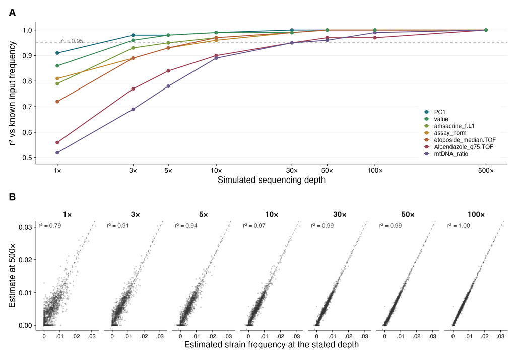

SUPP_FIG_XX_simulation_depth

Each wild isolate was assigned a fitness value drawn from an inverse χ² distribution; the expected pooled allele frequencies such a population would produce were computed; alt-allele counts were simulated by binomial sampling at 1, 3, 5, 10, 30, 50, 100 and 500×; and those counts were deconvolved back to per-strain frequencies by NNLS and compared with the known input. Seven published traits with validated QTL seeded seven independent populations of 327 strains.

A r² of estimated against known input frequency, against simulated depth, one line per trait. Every trait reaches 1.00 by 500×. At 1× the spread is wide — PC1 `0.91`, value `0.86`, assay_norm `0.81`, amsacrine_f.L1 `0.79`, etoposide_median.TOF `0.72`, Albendazole_q75.TOF `0.56`, mtDNA_ratio `0.52`; median `0.79`. The lowest depth from which a trait stays at or above 0.95 is 3× for PC1 and value, 5× for amsacrine_f.L1, 10× for assay_norm and etoposide_median.TOF, and 30× for Albendazole_q75.TOF and mtDNA_ratio.

B The archived estimates against the 500× estimate, faceted by depth, all seven traits pooled. Axes share limits so the dashed y = x line means the same thing in every facet. Pooled r² against 500×: `0.79` at 1×, `0.91` at 3×, `0.94` at 5×, `0.97` at 10×, `0.99` at 30× and 50×, `1.00` at 100×.

| Trait | 500× | 100× | 50× | 30× | 10× | 5× | 3× | 1× |
| --- | --- | --- | --- | --- | --- | --- | --- | --- |
| PC1 | 1 | 1.00 | 1.00 | 1.00 | 0.99 | 0.98 | 0.98 | 0.91 |
| value | 1 | 1.00 | 1.00 | 0.99 | 0.99 | 0.98 | 0.96 | 0.86 |
| assay_norm | 1 | 1.00 | 1.00 | 0.99 | 0.96 | 0.93 | 0.89 | 0.81 |
| amsacrine_f.L1 | 1 | 1.00 | 1.00 | 0.99 | 0.97 | 0.95 | 0.93 | 0.79 |
| etoposide_median.TOF | 1 | 1.00 | 1.00 | 0.99 | 0.97 | 0.93 | 0.89 | 0.72 |
| Albendazole_q75.TOF | 1 | 0.97 | 0.97 | 0.95 | 0.90 | 0.84 | 0.77 | 0.56 |
| mtDNA_ratio | 1 | 0.99 | 0.96 | 0.95 | 0.89 | 0.78 | 0.69 | 0.52 |

Derived from supplemental_data/deconvolution/simulation_reported_r2.tsv

This decides what the figure can be used for

**Only the NNLS output is archived.** The simulation script, the drawn fitness values and the expected input frequencies are all absent, as is the trait directory the original processing script reads. Panel A therefore **cannot be recomputed**: its values are read back out of text embedded in the original per-trait PDFs by `scripts/extract_sim_reported_r2.py`, the only surviving record of the comparison against the known input. Panel B *is* recomputed, but against the 500× estimate standing in for the truth — defensible, because panel A puts 500× at r² = 1.00 for all seven traits and the two agree where they can be compared (pooled convergence at 1× is 0.79 against a median reported accuracy of 0.79), but a stand-in all the same.

On the wording of the claim

“NNLS can accurately infer strain frequencies with as little as 1× sequencing depth” holds for the best-behaved traits and not for the worst: at 1×, r² runs from **0.91 down to 0.52**. What the whole figure supports is that 1× recovers most of the signal for most traits (median r² 0.79), that 10× suffices for five traits of seven, and that **30×** is the lowest depth at which all seven sit at or above 0.95.

Separately, 139 of 18,312 archived coefficients (0.8%) are negative, at depths 5 through 100. A strict non-negative solver cannot return those, so the archive carries solver or post-processing noise of order 1e-2 on the count scale. It changes no conclusion, but the archived values are not exactly a clean NNLS output.

## Figure S2 — the designed DNA mixture

**Script** `scripts/SUPP_FIG_XX_dilution_validation.R`  
**Validates** NNLS against a known input, with real counts  
**Design** 174 isolates in 4 sets; pure pools in triplicate + a 7-step B-into-C titration  
**Counts** GATK ASEReadCounter

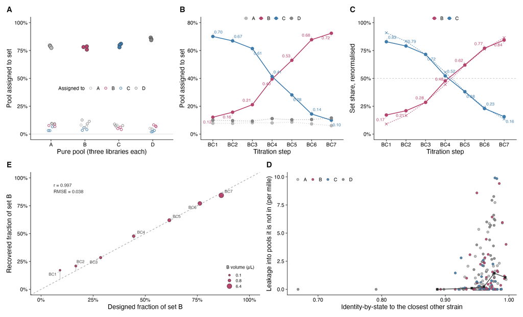

SUPP_FIG_XX_dilution_validation

A Pure pools, three libraries each. The fraction assigned to the pool’s own set is `0.785` (A), `0.775` (B), `0.796` (C), `0.853` (D) — filled points. The fraction misassigned to each other set runs `0.020`–`0.127`, mean `0.066` (open points); total misassigned per pool `0.135`–`0.242`.

B The titration on the 170-strain pool reference, each B and C value labelled. Set B rises monotonically 0.12 → 0.72 and set C falls monotonically 0.70 → 0.10 (Spearman ρ `+1` and `−1` against step). The two untitrated sets stay flat — A `0.061`–`0.086`, D `0.093`–`0.116`, drawn dotted.

C The same seven samples with the reference restricted to the 84 strains of sets B and C and renormalised — the analysis the original figure showed: B 0.17 → 0.84 against C 0.83 → 0.16, crossing between BC4 and BC5.

D Whether the strains that resolve badly are the genetically similar ones. For each of the 170 strains, x is identity-by-state to the closest *other* strain in the reference and y is its **leakage** — the mean frequency it picks up across the nine libraries of the three sets it is **not** in. That must be zero whatever the DNA input was, so unlike own-pool recovery it assumes nothing about the design. Grey squares are bin medians; points are coloured by the strain’s own set.

**Leakage rises with genetic similarity: Spearman ρ `+0.326`, `p = 1.4e-05`, n = 170.** Mean identity to all strains gives the same answer more weakly (ρ `+0.258`, `p = 6.8e-04`).

| Bin | Strains | Median leakage |
| --- | --- | --- |
| [0.66,0.9] | 5 | 0.00000 |
| (0.9,0.95] | 34 | 0.00010 |
| (0.95,0.97] | 75 | 0.00023 |
| (0.97,0.99] | 52 | 0.00143 |
| (0.99,1] | 4 | 0.00106 |

Derived from dilution_predictions_poolref.tsv.gz + dilution_strain_similarity.tsv

The ceiling and the leakage are one quantity, not two

For a pure pool the fractions sum to 1, so **own-set share = 1 − (mass assigned to strains not in the pool)**. Checked: `own + out = 1` to 4.4e-16 across all twelve pure pools, mean own-set share `0.802` against out-of-pool `0.198`. The ~0.8 ceiling in panel A *is* the leakage in panel D, seen from the other side.

**And the leakage is relatedness-directed.** Across the 1,530 strain-by-pool combinations where a strain is absent from the pool, mass assigned to it averages `1.33` per mille when its nearest neighbour is elsewhere and `2.25` per mille when its nearest neighbour is *in* that pool — a 1.70× enrichment, Mann-Whitney `p = 3.6e-05`. Those pairs are 24.3% of the combinations but carry **35.3%** of all out-of-pool mass. Rescaling, relatedness accounts for about **14%** of the out-of-pool mass, so it is a real contributor to the ceiling.

That 14% is a **lower bound**, because “nearest neighbour in the pool” is the crudest possible measure: a strain has many relatives among a pool’s ~43 members, not one. The proper test is mass against relatedness to *all* pool members, which needs the full genotype matrix.

What the per-strain null actually showed. `ρ(nn_ibs, own-pool recovery) = +0.046, p = 0.55` is about *per-strain* recovery, which is **bidirectional** — a strain both loses mass to confusable partners and gains it from them, and a trade with a partner in the same set does not move the set total at all. So per-strain recovery can show no correlation while relatedness drives every transfer. Leakage is unidirectional, which is why the signal survives there.

Restricting the reference does recover the input ratios better

Against the designed B fraction, in RMSE:

| estimate | RMSE | bias |
| --- | --- | --- |
| 170-strain reference, raw | `0.0788` | `−0.0593` |
| 170-strain reference, renormalised within B+C | `0.0415` | `+0.0297` |
| 84-strain B+C reference | `0.0376` | `+0.0208` |

Most of the damage is undone by renormalising — that removes the ~18% of mass sitting on sets A and D — and restricting the reference to the strains actually present recovers a further **9%**. So the panel B against panel C comparison reads the way you would expect: the fewer absent candidates the solver is offered, the closer the set frequencies land to the input.

One thing these data still **cannot** support: that the damage concentrates in near-identical pairs *split across sets*. Only 30 reciprocal nearest-neighbour pairs exist, two above IBS 0.99, so that comparison is underpowered and answers differently at different thresholds.

Both panels’ plotted fractions are pinned as literals in the script and checked against the deposit on every run, so these numbers cannot drift from the figure without the script failing.

### The renormalisation, step by step

There are two normalisations here and they do different things. The second one is why panel C looks the way it does, and it is worth being explicit about.

1 **Within each sample, after the solve.** NNLS fits the observed alt-allele counts of one sample as a non-negative combination of the reference strains’ genotypes, returning one coefficient per strain. Those coefficients are on an arbitrary scale — they grow with sequencing depth — so each sample’s vector is divided by its own sum. After this every sample’s strain frequencies sum to exactly 1 and read as “the fraction of this pool contributed by that strain”. The division is *within* a sample, so it cannot move signal between samples.

2 **Which strains the sum runs over.** Step 1’s denominator covers whatever is in the reference, so the reference decides what “the whole pool” means. On the **170-strain pool reference** (panels A, B) the denominator includes all four sets, so B + C comes to about `0.82` and the remaining `0.18` is assigned to the untitrated sets A and D. On the **84-strain B+C reference** (panel C) the reference contains only sets B and C, so the denominator runs over those strains alone and **B + C = 1 by construction**.

3 **Set-level sums.** Per-strain frequencies are added within a set. Nothing is renormalised at this stage.

What this means for reading panel C

**Panel C’s two series are exact complements because the normalisation makes them so, not because the inference discovered it.** B and C summing to 1 there carries no information. The informative quantity is in panel B, where the denominator is the whole panel and B + C is free to move — and it barely does, which is metric 1 below.

Before either normalisation, markers were restricted to mean depth above 5 and below 100 across samples, high-frequency variants were recoded so the minor allele is counted throughout, and sites with any missing genotype were dropped.

### How far off was the inference?

| Sample | Set B | Set C | B + C | A + D |
| --- | --- | --- | --- | --- |
| BC1 | 0.121 | 0.701 | 0.822 | 0.178 |
| BC2 | 0.157 | 0.669 | 0.826 | 0.174 |
| BC3 | 0.211 | 0.614 | 0.825 | 0.175 |
| BC4 | 0.395 | 0.413 | 0.808 | 0.192 |
| BC5 | 0.530 | 0.281 | 0.811 | 0.189 |
| BC6 | 0.678 | 0.144 | 0.822 | 0.178 |
| BC7 | 0.724 | 0.100 | 0.824 | 0.176 |

Derived from supplemental_data/deconvolution/dilution_predictions_poolref.tsv.gz

**Metric 1 — conservation of the titrated pair. Assumes nothing about the design, and is the one to quote.** Only B and C are titrated against each other, so whatever the intended proportions were, the pair’s combined share of the pool has to stay constant across BC1–BC7: moving DNA from C to B cannot change how much of the pool is B-or-C. Any wobble in `B + C` is therefore inference error, measurable without knowing a single nominal ratio. Observed: mean 0.8198, sd 0.0070 (0.86% of the mean), largest deviation 0.0113 (1.38%). **The pair is conserved to better than 1.5% across a titration that moves each set sixfold**, which bounds the inference error without invoking the design at all.

**Metric 2 — deviation from the designed series.** The design was recovered from the lab record on 2026-09-08 and is in `supplemental_data/deconvolution/dilution_design.tsv`: a two-fold doubling series of set B against a fixed 1 µL of set C, made up to 10 µL with water. Stocks measured 100 ng/µL (B1) against 99.9 ng/µL (C1), so the DNA mass fraction equals the volume fraction to within `2.5e-4` — the equal-concentration assumption is verified, not assumed, and the correction is four orders of magnitude below the error being measured.

Recovery tracks the design at **Pearson r = 0.997**, **RMSE 0.038** in fraction units, Spearman ρ `+1`:

| Sample | B (µL) | Total DNA (ng) | Designed | Recovered | Deviation |
| --- | --- | --- | --- | --- | --- |
| BC1 | 0.1 | 11 | 0.091 | 0.171 | +0.080 |
| BC2 | 0.2 | 12 | 0.167 | 0.209 | +0.043 |
| BC3 | 0.4 | 14 | 0.286 | 0.285 | -0.001 |
| BC4 | 0.8 | 18 | 0.445 | 0.478 | +0.033 |
| BC5 | 1.6 | 26 | 0.616 | 0.620 | +0.004 |
| BC6 | 3.2 | 42 | 0.762 | 0.771 | +0.009 |
| BC7 | 6.4 | 74 | 0.865 | 0.843 | -0.022 |

Derived from dilution_design.tsv + dilution_predictions_bcref.tsv.gz

**Metric 3 — shape.** The recovered B share is linear in titration step with R² `0.974`, and Spearman ρ `+1` against both step and designed fraction.

E Recovered against designed fraction of set B, point area giving the volume of B pipetted. This is the accuracy panel, and it exists because the design was recovered.

The error is unreplicated, and one step dominates it

**There are no replicate dilutions**, so pipetting error enters the comparison in full. The largest deviation is at **BC1** (`+0.080`), whose B volume is 0.1 µL — the smallest and hardest-to-pipette volume in the series. Dropping BC1 halves the error to RMSE `0.024`, max `0.043`. Deviation does trend with 1/volume across the series, but not significantly at n = 7 (Spearman `+0.50`, `p = 0.27`), so the pipetting explanation is mechanistically plausible and statistically unproven.

**Total DNA is not constant** across the series either — 11 ng at BC1 rising to 74 ng at BC7, because only the B volume varied. Input mass and B fraction are therefore perfectly confounded, and a deviation that scaled with total DNA would be indistinguishable from one that scaled with B fraction.

**The bias runs toward B**: mean deviation `+0.021` on the B+C reference, `+0.030` on the pool reference. Stock concentration is excluded as the cause (100 vs 99.9 ng/µL). Set B holds 46 of the 84 reference columns against set C’s 38, which is a candidate explanation and is not tested here.

One isotype is assigned to two sets, and it is not cosmetic

Strains JU1580 and JU1793 are the same isotype, and the experiment put them in sets B and D. The deconvolution returns one frequency for the pair, so the source tables carry that isotype **twice** — once labelled B, once D. Summed naively the single estimate is added to both sets, where it is **5–19% of set D’s apparent frequency** in BC1–BC7 and *rises across the titration*, making the untitrated set D appear to drift upward. The figure resolves it to set B — what the original analysis did, and what the estimate’s own behaviour says — and asserts no other isotype is ambiguous. This is the same strain whose duplicated genotype-reference entry is documented for the *pos-1* phenotype, and it is a cross parent in Figures 2 and 3.

Two further limits

Pure-pool recovery tops out near 0.8, not 1.0, so roughly a fifth of each pool is assigned to strains that are not in it — and that fifth *is* the leakage of panel D, since the two sum to 1 by construction. Relatedness demonstrably directs it (1.70× enrichment when the absent strain’s nearest neighbour is in the pool, `p = 3.6e-05`) and accounts for at least ~14% of it. The rest is not attributed here: cross-contamination between pools and unequal DNA input across strains within a pool remain candidates these data cannot separate.

Panels A and B use the 170-strain pool reference and panel C the 84-strain B+C reference. After renormalising the pool reference within B and C the two disagree by at most `0.054`, mean `0.029`, on the same samples — the size of the reference-choice effect. The deposit also carries the 540-strain full-panel and regenotyped references.

## Figure 1 — the validated assay, the phenotype it produces, and the map

**Script** `scripts/Figure1_pos1.R`  
**Test bed** Baugh L1 starvation, the one dataset with pooled WGS and published MIP-seq on the same samples  
**n** 98 strains (A) · 231 strains (B, C) · 464,045 markers

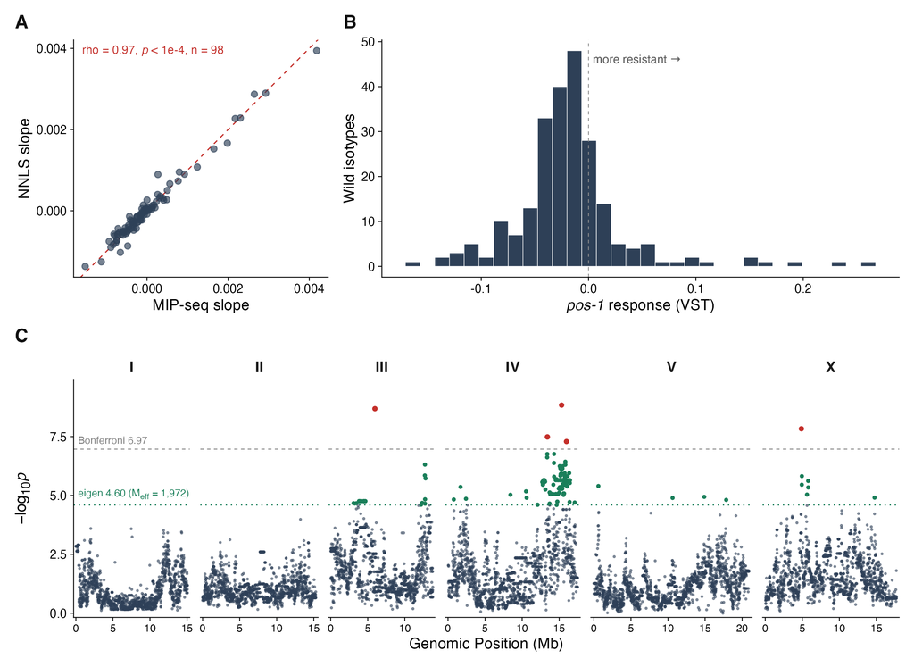

plots/Figure1_pos1.pdf · .png

A Per-strain rate of change in pool frequency during L1 starvation, MIP-seq against NNLS, one point per wild isolate averaged over five replicate arms — `n = 98`, Spearman `ρ = 0.97`, `p < 1e-4`. Slopes are the regression of frequency change on day, taking day 1 as baseline and excluding day 17. The dashed line is `y = x`, not a fit.

B Distribution of the 2023 pooled *pos-1* RNAi response across wild isotypes on the vst scale (`n = 231` strains with a vst value, of 366 in the trait file). The dashed line marks zero; positive values are strains that gained pool frequency under *pos-1* RNAi, i.e. resistant.

C GEMMA LOCO association scan for that phenotype: 464,045 markers, `n = 231`. The grey dashed line is Bonferroni over every marker (`6.97`); the green dotted line divides α by the 1,972 effective independent tests (`4.60`). Markers clearing Bonferroni are red, markers clearing only the eigen threshold are green. **Ten markers clear Bonferroni and 465 clear the eigen threshold.** The maximum is `8.84` on chromosome IV at 15.323 Mb; eight of the ten lie on chromosome IV, in clusters near 13.41 and 15.32 Mb, with single markers on chromosome III at 5.966 Mb (`8.68`) and chromosome X at 4.876 Mb (`7.83`). **None is near the chromosome III interval the NILs resolve** — the chromosome III association peak is 7.7 Mb from it.

Two things to state in the text

N2 is excluded from panel A throughout: as the reference strain its genotype shares sites with every other strain in the pool, so its NNLS frequency is not identified on the same footing as the wild isolates’.

The shipped vst value for JU1793 still carries the duplicate-entry averaging documented in `scripts/2023_pos1_analysis.R` — which matters, because JU1793 is a cross parent in Figures 2 and 3.

## Figure S3 — the sample-level measurements behind the Figure 1 slopes

**Script** `scripts/SUPP_FIG_XX_baugh_per_sample_frequencies.R`  
**Supports** Figure 1A · 15 samples used by the slope fits

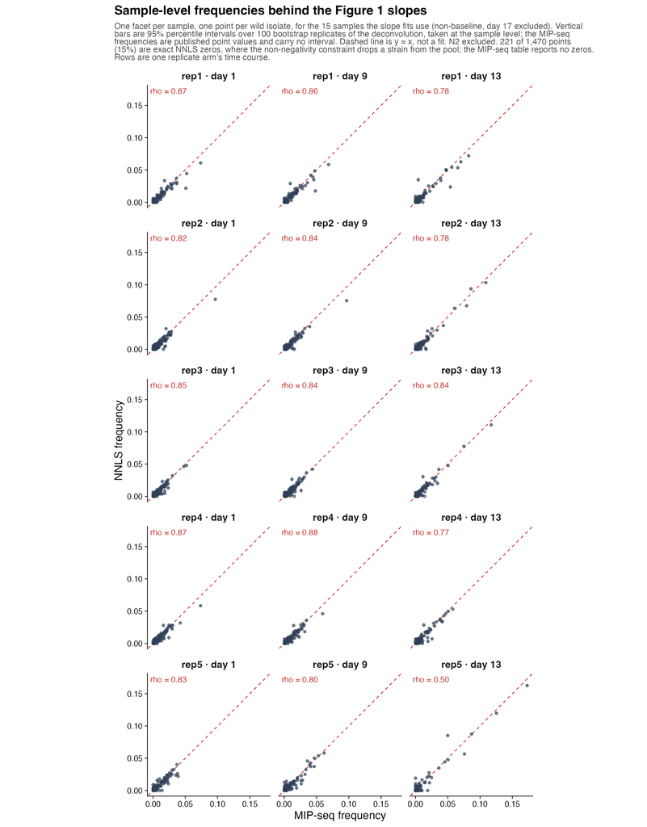

SUPP_FIG_XX_baugh_per_sample_frequencies

One facet per sample for the 15 samples the slope fits use (non-baseline, day 17 excluded), one point per wild isolate, published MIP-seq frequency against NNLS frequency, with 95% percentile intervals over 100 bootstrap replicates of the deconvolution taken at the sample level. Rows are one replicate arm’s time course; Spearman ρ is given per facet. Dashed line is `y = x`, not a fit; N2 excluded.

Vertical bars only: the published MIP-seq frequencies are point values with no distributed uncertainty, so an interval on that axis would be invented.

Two things Figure 1 cannot show. First, `rep5_d13` agrees far worse than any other sample (`ρ = 0.50` against 0.77–0.88 elsewhere) and is the single low bar in the per-sample distribution. Second, 221 of 1,470 points (15%) are exact NNLS zeros — the non-negativity constraint clamping a strain out of a pool — while the MIP-seq table reports no zeros at all. A block of ties at zero cannot be ranked, which is the likely reason per-sample ρ (median 0.84) is so much lower than the slope-level 0.97.

## Figure S4 — the bootstrap propagation checks

**Script** `scripts/SUPP_FIG_XX_bootstrap_propagation_checks.R`  
**Supports** the bootstrap intervals · 100 replicates

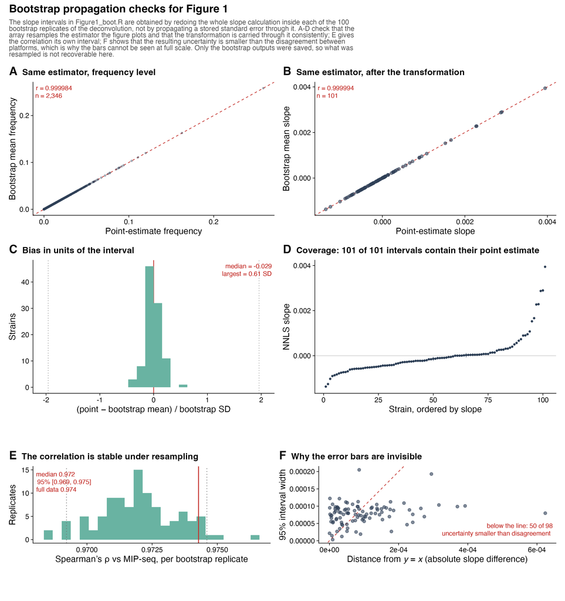

SUPP_FIG_XX_bootstrap_propagation_checks

The intervals are obtained by redoing the whole slope calculation inside each of the 100 bootstrap replicates of the deconvolution, not by propagating a stored standard error through that chain. Each panel is a check that could have failed.

A Frequency level: bootstrap mean against point estimate, *r* = `0.999984`, `n = 2,346`. Confirms the array resamples the estimator Figure 1 plots.

B The same after the transformation, *r* = `0.999994`, `n = 101`. This is the panel that would break if the day-1 baseline were taken from the point estimate rather than from within each replicate, or if the replicate arms were averaged in the wrong order.

C Standardised bias, (point estimate − bootstrap mean) / bootstrap SD: median −0.029, largest 0.61 SD. Dotted lines at ±1.96.

D Coverage: each strain’s interval with its point estimate marked. All 101 of 101 intervals contain their own point estimate.

E The correlation’s own bootstrap distribution: median 0.972, 95% percentile interval `[0.969, 0.975]`, full-data value 0.974.

F Bootstrap interval width against distance from `y = x`, per strain. The uncertainty is smaller than the platform disagreement for 50 of 98 strains, and 0.57× it on average — which is why the bars are invisible at full scale.

Caveat, and it is not resolvable from the archived data

Only the bootstrap outputs were saved. The archive holds the 102 × 23 × 100 array and a reshaped copy of it, not the resampling scheme, and the generating code is not in this repository. These panels establish that the array resamples the plotted estimator and that the transformation is carried through it consistently. They cannot establish *what* was resampled — reads, markers or strains. No statement stronger than “100 bootstrap replicates of the deconvolution” is supported by what is on disk.

## Figure S5 — the sequencing-depth requirement

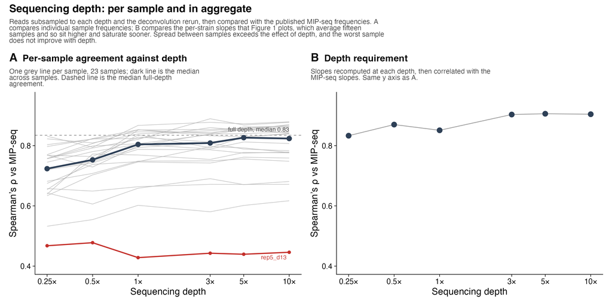

SUPP_FIG_XX_downsample_per_sample

A Per-sample agreement against depth: one grey line per sample (23 samples), dark line the median across samples, dashed line the median full-depth agreement (0.835). Median ρ rises 0.724 at 0.25× to 0.827 at 5×, saturating by 3–5×.

Panel B correlates slopes, which average fifteen measurements, so it sits above A at every depth and saturates sooner: averaging removes most of what depth costs an individual sample. **Quoting the depth requirement from B alone overstates how well any single sample is measured.**

Two further points. The spread between samples exceeds the effect of depth — the median moves about 0.10 across a fortyfold depth range while samples span roughly 0.43 to 0.88 at any fixed depth. And `rep5_d13` is worst at every depth (0.428–0.478) without improving, so its disagreement is not a depth problem and no amount of sequencing would have fixed it.

## Figure S6 — replicate reproducibility of the phenotype

**Script** `scripts/SUPP_FIG_XX_original_pos1_dfreq_rep_correlation.R`  
**Supports** the Figure 1B phenotype · all 6 pairwise comparisons of 4 replicates

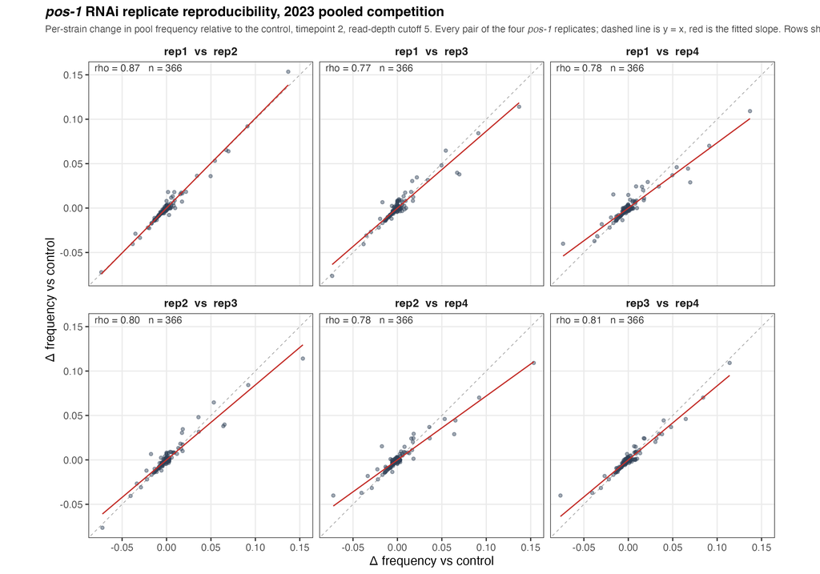

SUPP_FIG_XX_original_pos1_dfreq_rep_correlation

All six pairwise comparisons of the four *pos-1* replicates, at read-depth cutoff 5, with Spearman ρ and n on each facet. Dashed line is `y = x`; red is the fitted slope.

Depth cutoff 5 is used because it is the cutoff the shipped association traits were built from: taking the mean *pos-1* delta per strain at cutoff 5 reproduces `delta_ctrl_pos-1_T2` to `2.5e-16`, against *r* = `0.9998` at cutoff 3 and `0.9988` at cutoff 10.

One strain needs a sentence

Rows sharing a (strain, sample) key are summed before the delta is taken. This affects JU1793 only, which appears twice per sample at every depth cutoff and in both arms — one row carrying the real frequency and the other `~1e-21`. That is NNLS splitting one strain’s abundance across two identical entries in the genotype reference, not two measurements. Summing roughly doubles JU1793’s *pos-1* delta, from 0.00857 to about 0.0171. For every other strain the collapse is a no-op.

## Figure S7 — the plate assay, validated externally

**Script** `scripts/SUPP_FIG_plate_vs_paaby_vs_pos1original.R`  
**Supports** the pooled phenotype, against two independent measurements  
**n** 111 strains (A) · 19 strains (B)

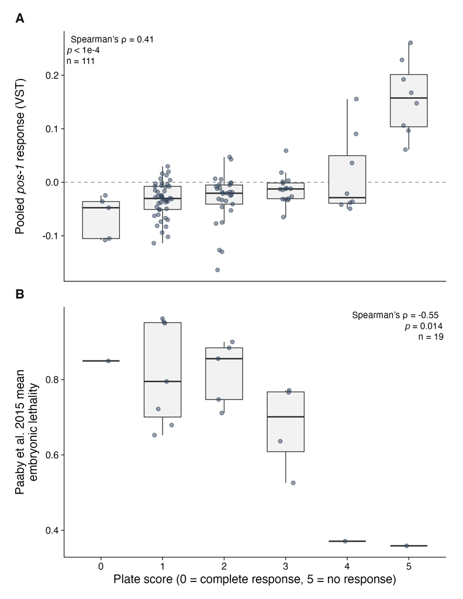

SUPP_FIG_plate_vs_paaby_vs_pos1original

The plate score is a six-level ordinal scale (0 = complete RNAi response/sensitive, 5 = no response/resistant), so Spearman rank correlation is used throughout: it requires only a monotonic relationship, not shared units or linearity.

A Plate score against the pooled 2023 *pos-1* response on the VST scale (`vst_ctrl_pos-1_T2`), the same trait the association mapping was run on: `ρ = 0.41`, `n = 111`, `p = 7.8e-06`. Positive is the expected direction — VST is positive for strains that gained pool frequency under *pos-1* RNAi, and resistant strains score high on the plate. Dashed line marks zero.

B Plate score against Paaby et al. 2015 mean embryonic lethality for the *pos-1* clone, computed per well as unhatched eggs over eggs plus larvae and averaged within a strain: `ρ = −0.55`, `n = 19`, `p = 0.014`. Negative is the expected direction — a low plate score means sensitive, and sensitive means high lethality.

Both agree with the plate assay in the predicted direction. **The Paaby comparison rests on 19 shared strains and should be described as consistent rather than as independent confirmation.**

Rebuilt on the VST trait

The earlier version of panel A used a bootstrap frequency change from a different export (`ρ = 0.42`, `n = 106`), which was on no scale used elsewhere in the manuscript. The VST version puts it on the same scale as every other phenotype panel.

# II. The map

genome-wide · two crosses

Pooled GWAS and F2 bulk-segregant cross mapping identify overlapping loci, and the two cross contrasts separate general RNAi-response loci from knockdown-specific ones.

## Figure 2 — pooled GWAS and cross mapping identify overlapping loci

**Script** `scripts/Figure2.R`  
**GWAS** n = 84 strains · 322,010 markers  
**Crosses** N2 × XZ1516 · JU1793 × JU2466  
**Drawn** QTL with peak LOD > 100 (9 intervals)

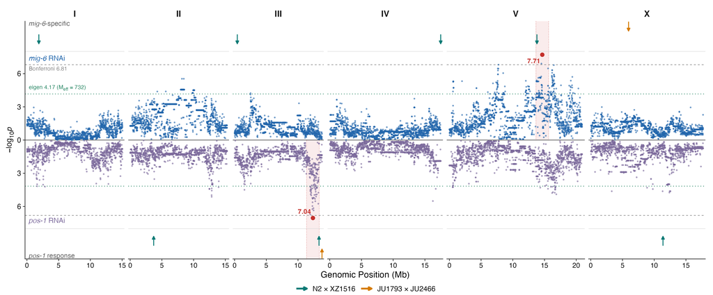

plots/Figure2.pdf · .png

Mirrored Manhattan of the pooled GWAS on the vst traits: the *mig-6* response above the axis, the *pos-1* response below (`n = 84`, 322,010 markers). Grey dashed lines are Bonferroni over every marker (`6.81`); green dotted lines divide α by the 732 effective independent tests (`4.17`). Threshold labels sit in the chromosome I panel.

Arrowheads mark the F2 cross QTL, one per QTL at its peak marker, coloured by cross and directional: *mig-6*-specific QTL above the axis, the *pos-1* response below. The *mig-6* arrows come from the *mig-6*-vs-*pos-1* contrast and the *pos-1* arrows from the HT115-vs-*pos-1* contrast, so each side shows the comparison that isolates the effect it is labelled with. Shaded vertical bands mark ±1 Mb around the pooled GWAS peaks.

Why the intervals became arrows

The arrows carry **position only** — no interval width, no peak LOD. The previous version drew each QTL as an interval bar with opacity scaled to LOD, which gave three visual channels to a mark that reliably carries one.

The width in particular was not what it appeared to be. A cross interval is often a few tens of kb against a 15–20 Mb axis, so every bar had to be padded to a `0.09` Mb minimum just to be visible — at which point the drawn width *was the padding*, not the interval, and the figure implied a precision the data do not have. Widths and peak LODs are in the table below, where a number needing three significant figures belongs.

`plots/Figure2_no_cross_qtl.png` is the same figure with the cross QTL removed altogether — the mirrored Manhattan alone, tracks, labels and cross legend dropped — written by the same script for comparison.

| Track | Cross | Chr | Peak Mb | Interval | kb | LOD |
| --- | --- | --- | --- | --- | --- | --- |
| *mig-6* vs *pos-1* | N2×XZ1516 | I | 1.88 | 1.80–1.96 | 166 | 751 |
| *mig-6* vs *pos-1* | N2×XZ1516 | III | 0.43 | 0.28–0.59 | 304 | 165 |
| *mig-6* vs *pos-1* | N2×XZ1516 | IV | 17.49 | 17.44–17.49 | 52 | 167 |
| *mig-6* vs *pos-1* | N2×XZ1516 | V | 13.81 | 13.63–13.91 | 278 | 730 |
| *mig-6* vs *pos-1* | JU1793×JU2466 | X | 5.96 | 5.66–6.24 | 582 | 361 |
| HT115 vs *pos-1* | N2×XZ1516 | II | 3.71 | 3.59–3.80 | 212 | 148 |
| HT115 vs *pos-1* | N2×XZ1516 | III | 13.31 | 13.11–13.50 | 394 | 710 |
| HT115 vs *pos-1* | JU1793×JU2466 | III | 13.78 | 13.73–13.78 | 51 | 140 |
| HT115 vs *pos-1* | N2×XZ1516 | X | 11.38 | 11.13–11.62 | 492 | 183 |

Transcribed from `Figure2.R` console output; there is no interval table in the deposit to derive this from. Only these nine are drawn — the complete significant set is the legacy supplement `SUPP_FIG_XX_cross_qtl_all`.

State this in the text rather than leave a reader to notice it

**No cross interval contains its matching pooled GWAS peak marker.** The nearest correspondences are the *mig-6* peak at V:14.65 Mb against the N2×XZ1516 chromosome V interval at 13.81 Mb (0.84 Mb apart), and the *pos-1* peak at III:12.35 Mb against the N2×XZ1516 chromosome III interval at 13.31 Mb (0.96 Mb) and the JU1793×JU2466 interval at 13.78 Mb (1.43 Mb). A GWAS on 84 strains is not expected to localise to a cross interval; the claim is concordance of *locus*, not of marker.

## Figure S8 — why these cross parents

**Script** `scripts/SUPP_FIG_XX_pooled_phenotype_ranks.R`  
**Supports** the choice of cross parents · n = 84 of 93 panel strains

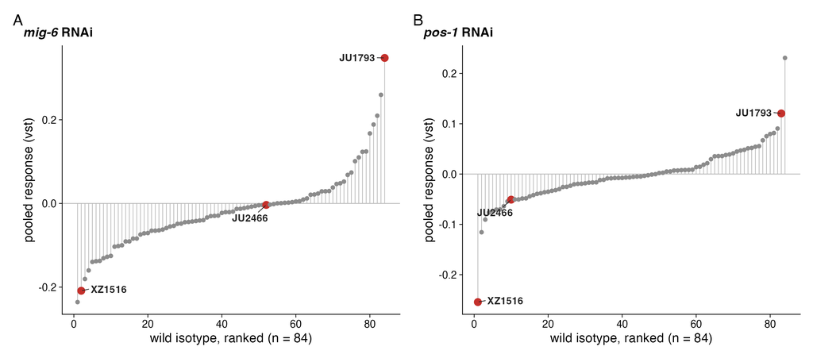

SUPP_FIG_XX_pooled_phenotype_ranks

Per-strain pooled RNAi response for *mig-6* and *pos-1* on the vst scale, ranked, with the cross parents highlighted. Establishes that the crosses were built from the extremes of the pooled assay rather than from convenience. Nine of the 93 panel strains have no vst value, so `n = 84` and ranks are out of 84.

## Figure S9 — the expanded view behind Figure 2’s tracks

**Script** `scripts/SUPP_FIG_XX_cross_contrast_panels.R`  
**Supports** Figure 2’s compressed tracks  
**Contrasts** HT115-vs-*pos-1* · *mig-6*-vs-*pos-1*

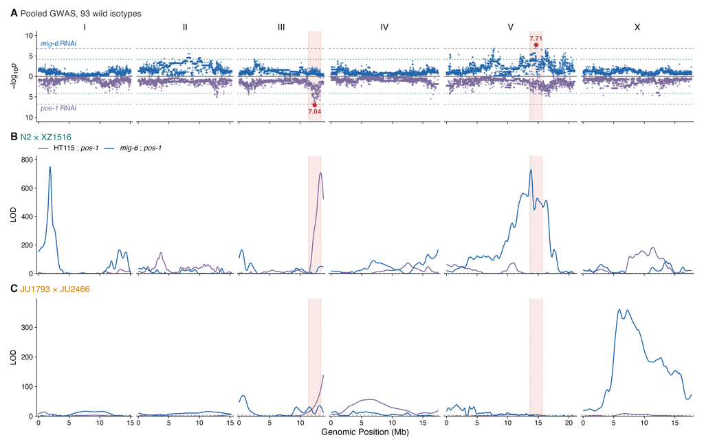

SUPP_FIG_XX_cross_contrast_panels

Mirrored pooled GWAS on top, then one panel per cross with both contrasts overlaid: HT115 vs *pos-1* in purple and *mig-6* vs *pos-1* in blue.

Purple high with blue flat marks a **general** RNAi-response locus — the machinery is affected whatever the target — and blue high marks a **knockdown-specific** one. This is the panel that justifies calling the chromosome III locus general and the chromosome V, I and X loci specific.

# III. The interval

13.8 Mb → 37 kb

A near-isogenic line series on the right arm of chromosome III fine-maps the general RNAi-response QTL to 37 kb, and gives an allelic series in hatching.

## Figure 3 — NILs fine-map the chromosome III QTL to 37 kb

**Script** `scripts/Figure3_quad.R` · 50% *pos-1* RNAi  
**Cross** JU1793 × JU2466, HT115 vs *pos-1*  
**chrIII peak** 13.784 Mb, LOD 139.7 · **resolved** 13.658–13.695 Mb (37 kb)

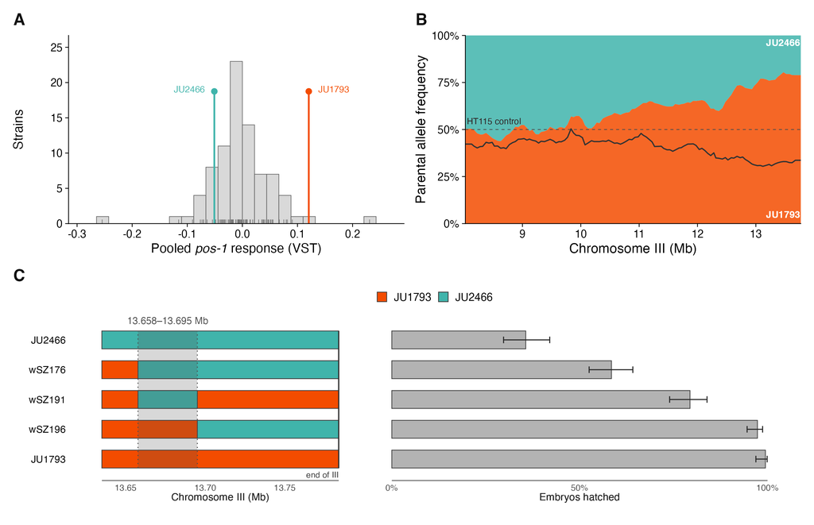

plots/Figure3_quad.pdf · .png

Three panels, arranged so the figure reads in the order the argument runs: two strains at opposite ends of the pooled panel, crossing them drives one parent’s haplotype toward the QTL, and NILs carrying pieces of it give an allelic series whose genotypes and phenotypes sit side by side.

A The pooled *pos-1* phenotype distribution as a histogram, with both cross parents marked by equal-height lollipops — JU1793 vst 0.121, rank 83/84; JU2466 −0.051, rank 10/84. This makes visible that the cross was built from opposite ends of the pooled panel.

Why a frequency trace instead of a LOD trace

A LOD trace answers whether there is a QTL here, which Figure 2 already answers. It says nothing about **which parent’s allele** the selection favoured, and that is the claim this panel is making: *sid-2* sits at 13.68 Mb, and the resistant parent’s haplotype is what sweeps toward it.

Two details that matter for trusting it. Frequencies are **count-weighted** — counts summed within each bin and the frequency taken from the sums — so a marker with 200 reads counts for more than one with 4; averaging per-marker frequencies would let the shallowest markers pull the trace around. And the parent assignment is taken from the cross export’s own README (`p1`/`p2` are the JU1793 and JU2466 haplotypes), not inferred: a swap would invert the panel and still look plausible, so the script asserts that the *pos-1* pool ends up more JU1793 than the control at the right end and stops if it does not.

C The NIL series with **genotype and phenotype in one panel**, one row per strain, JU1793 at the bottom to JU2466 at the top. Left, the introgressions on the right arm of chromosome III, 13.635 Mb to the telomere, JU1793 genotype in orange and JU2466 in teal — the smaller half of the panel, on thin bars, because it carries two breakpoints where the hatching carries a five-level series with intervals. Right, embryos hatched under 50% *pos-1* RNAi on the same rows, one plate per strain with Wilson 95% binomial intervals. The two halves share the row axis and carry separate x scales, labelled beneath each.

| Strain | Embryos | Hatched |
| --- | --- | --- |
| JU1793 | 179 | 99.4% |
| wSZ196 | 261 | 97.3% |
| wSZ191 | 252 | 79.4% |
| wSZ176 | 272 | 58.5% |
| JU2466 | 230 | 35.7% |

Derived from supplemental_data/hatching_assays/nil_series_hatching.tsv

The introgressions run to the end of the chromosome

This is what distinguishes the strains, so the panel says it rather than leaving it to be inferred. Five of the six NILs carry a JU2466 segment that begins at a breakpoint and continues to the chromosome III terminus at **13,783,801 bp**, which the right-hand edge of the genotype track marks. **wSZ191 is the exception** — an internal 13.658–13.695 Mb segment that stops short.

That contrast is the fine-mapping argument: wSZ191 carries the resolved interval and nothing distal to it, wSZ196 carries everything distal and not the interval, and their hatching differs (`79.4%` against `97.3%`). So compressing the axis to the breakpoints alone would crop exactly the fact the panel exists to show; the window keeps its right edge at the terminus, and the compression is in the left flank and the row height instead.

The shaded band with dotted edges is the interval the series resolves, **13.658–13.695 Mb** — the region wSZ191 carries and wSZ196 does not.

Previously two panels C (hatching) and D (genotypes) drew the same five strains as rows twice, in two panels with two x axes, so pairing a genotype with its phenotype meant carrying a row position across a panel boundary. The two-panel functions are still in `Figure3_common.R` — `Figure3_chrIII.R` and the supplements use them.

Two caveats, the second worth a sentence in the text

1. One plate per strain per condition, so the hatching intervals in C describe *counting* uncertainty, not between-plate variability, and no strain is replicated. The ordering should be read as an allelic series, not as a set of tested contrasts. The HT115 control arm and four further NILs are in the supplement below.
2. The chromosome III peak marker at 13.784 Mb **is the terminal marker of the chromosome**. A scan cannot place a peak past the chromosome end, so that position is a boundary artefact rather than a localisation, and the NIL interval at 13.658–13.695 Mb is the claim. “The peak coincides with the NIL interval” is not a sentence these data support.

## Figure S10 — the complete NIL hatching experiment

**Script** `scripts/SUPP_FIG_XX_nil_hatching_full.R` · 50% *pos-1* RNAi  
**Supports** Figure 3C · 10 strains, both food conditions

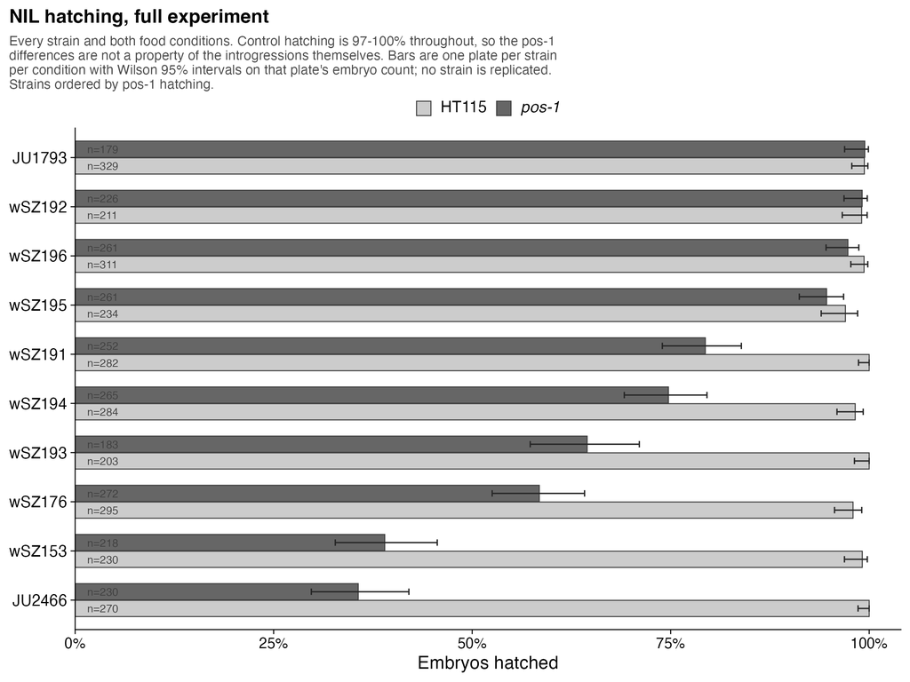

SUPP_FIG_XX_nil_hatching_full

All 10 strains on both food conditions at 50% *pos-1* RNAi, strains labelled and ordered by *pos-1* hatching, with embryo counts on each bar and Wilson 95% binomial intervals. **Control hatching is 97–100% for every strain**, which is what makes the *pos-1* differences in Figure 3C attributable to the RNAi rather than to the introgressions themselves.

Adds four NILs that Figure 3 does not use — wSZ192, wSZ193, wSZ194, wSZ195 — and wSZ153.

None of the four has introgression coordinates in the NIL ranges file, so their genotypes cannot be drawn. **wSZ192 and wSZ193 in particular would sharpen the interval if their breakpoints can be recovered.** One plate per strain per condition, as in Figure 3C.

# IV. The residue

one residue

Editing *sid-2* residue 96 moves RNAi sensitivity in three genetic backgrounds and in both directions, and the residue sits on the lumenal face of the ectodomain alongside residues already known to be required for dsRNA uptake.

## Figure 4 — editing *sid-2* residue 96 moves sensitivity in three backgrounds

**Script** `scripts/Figure4_sid2.R`  
**Assets** `scripts/sid2_ribbon_render.py` · `scripts/sid2_zoom_render.py`  
**Variant** chrIII:13,680,248 C>A · T96K  
**Dose** 50% *pos-1* (A) · **25%** *pos-1* (B)

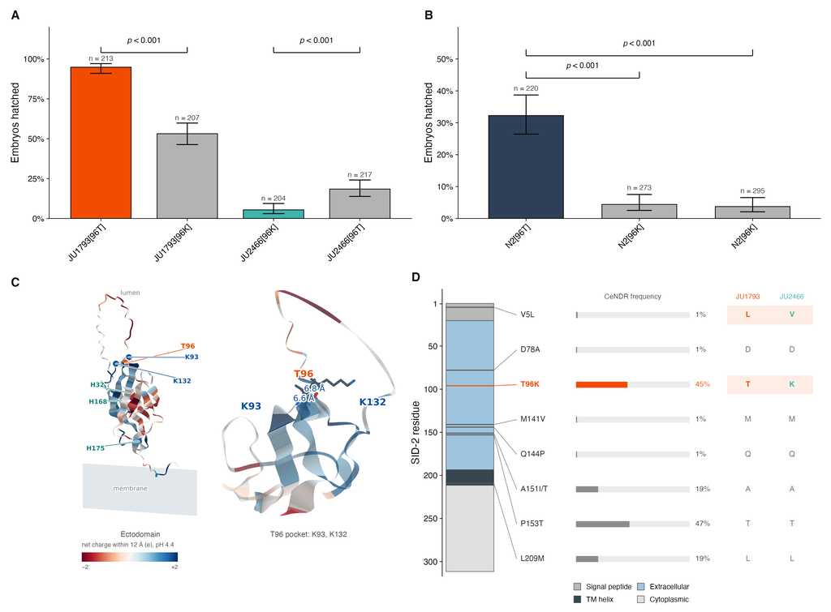

plots/Figure4_sid2.pdf · .png

Panels carry letters only; all descriptive text is here.

A Embryos hatched on **50%** *pos-1* RNAi for reciprocal edits at residue 96 in the two cross parents. JU1793[96T], the resistant parental allele, 94.8% (`n = 213` embryos); JU1793[96K] 53.1% (`n = 207`); JU2466[96K], the sensitive parental allele, 5.4% (`n = 204`); JU2466[96T] 18.4% (`n = 217`). Parental alleles are in the strain colours and edited alleles in grey. Fisher’s exact test, each edit against the unedited allele in the same background: `p = 1.7e-24` and `p = 3.9e-05`. Editing 96T→K removes most of JU1793’s resistance and 96K→T recovers part of JU2466’s, so residue 96 contributes in both directions without accounting for the whole difference between the parents.

B The same substitution in N2, at **25%** *pos-1* RNAi. N2 carries 96T and hatches 32.3% (`n = 220`); two independently derived lines edited to 96K hatch 4.4% (wSZ203, `n = 273`) and 3.7% (wSZ204, `n = 295`), Fisher `p = 7.8e-17` and `p = 6.2e-19`. The two edited lines are labelled by genotype and not distinguished on the axis, because they are independent lines of the same edit. This is the third genetic background to show the effect and the only one with two independent edits, and the direction is the same throughout: **96K sensitive, 96T resistant**.

C The SID-2 ectodomain coloured by **local net charge**, AlphaFold3 model, rotated onto the membrane normal so the intestinal lumen is up; the grey slab is the bilayer. Colour is the net side-chain charge of every ectodomain residue with a Cα within 12 Å, by Henderson–Hasselbalch at pH 4.4 — the gut-lumen pH at which SID-2 functions — on a diverging scale saturating at ±`2` e, red negative and blue positive. Left, residues 21–188 of chain A: T96 (orange), the two lysines that make its pocket, K93 and K132 (blue), and SID-2’s three extracellular histidines H32, H168 and H175 (teal). Right, the pocket enlarged, with Cα distances from T96 of `6.6` Å to K93 and `6.8` Å to K132 (nearest heavy atoms `4.5` and `4.4` Å).

Why this panel is about charge and not about shape

The panel used to be coloured by secondary structure, which showed the fold — not the argument, and not anything in dispute. The argument is electrostatic, and it rests on a precedent running the same direction as our own result.

SID-1’s dsRNA recognition is **electrostatic and sequence-independent**: basic side chains against the phosphate backbone, no sequence preference. That transfers as physics without any fold relationship, which matters because the fold relationship does *not* hold — an unrelated immunoglobulin domain scores higher against the SID-2 model (TM `0.427`) than SID-1’s BRD1 does (`0.404`), while the two genuine BRDs of SID-1 score `0.525` against each other. The resemblance is the background level for any compact β-sandwich of this size. Nothing in the manuscript claims otherwise, and nothing should: do not superpose the 8XC1 dsRNA onto this model.

What the charge measurement says: the ectodomain is net **acidic** overall (`−8.34` e at pH 7.4, `+0.47` e at pH 4.4 across the modelled 21–188), yet T96’s own neighbourhood is `+1.24` e — the **82nd percentile** of the domain — and T96K takes it to `+2.24` e, the **98th**. T96 is solvent-exposed at the domain median (SASA `62.4` Å², 48th percentile), so the side chain is available. The precedent: the triple His→Arg mutant of McEwan et al. internalised **more** dsRNA than wild type — replacing pH-dependent positive charge with permanent positive charge increased uptake. T96K adds permanent positive charge to the same surface and increases RNAi sensitivity in all three backgrounds.

D *sid-2* coding variation in the wild population: the protein drawn vertically with residue 1 at the top and its topology as a filled bar, and each protein-altering variant labelled to the right with its CeNDR allele frequency, then two columns giving the JU1793 and JU2466 allele state. Callout rows are evenly spaced and joined to the residue by a leader rather than sitting at the residue’s own height: four of the eight fall between residues 141 and 153 and would overlap completely at true scale.

| Variant | Residue | CeNDR AF | Isotypes | JU1793 | JU2466 | N2 | XZ1516 | Parents differ |
| --- | --- | --- | --- | --- | --- | --- | --- | --- |
| V5L | 5 | 0.015 | 540 | L | V | V | V | yes |
| D78A | 78 | 0.009 | 540 | D | D | D | A |  |
| T96K | 96 | 0.453 | 537 | T | K | T | K | yes |
| M141V | 141 | 0.009 | 540 | M | M | M | V |  |
| Q144P | 144 | 0.009 | 540 | Q | Q | Q | P |  |
| A151I/T | 151 | 0.195 | 539 | A | A | A | I/T |  |
| P153T | 153 | 0.470 | 538 | T | T | P | T |  |
| L209M | 209 | 0.195 | 539 | L | L | L | M |  |

Derived from supplemental_data/structure/sid2_variants_cendr.tsv

Panel D is not an exhaustive catalogue: the amino-acid annotation covers variants segregating among the four cross parents. 81 variants of any kind segregate in the 3 kb span in CeNDR, and the 8 protein-altering ones above are what is annotated.

Linkage, and why it does not confound the cross

T96K and P153T are in near-complete linkage disequilibrium across the wild population, r² = 0.935: 96K never occurs without 153T, though 153T occurs without 96K in nine isotypes. **Both cross parents carry 153T** — JU1793 is 96T/T153 and JU2466 is 96K/T153 — so P153T does not segregate in the JU1793×JU2466 cross and cannot account for the mapped effect.

Of the 8 annotated coding variants, only 2 differ between the two parents: **V5L and T96K**. That narrows the cross’s candidate coding changes to two by inspection.

## Figure S11 — the full N2 dose series

**Script** `scripts/SUPP_FIG_XX_n2_swap_dose.R`  
**Supports** Figure 4B’s dose choice · doses 0, 25, 50, 75, 100%

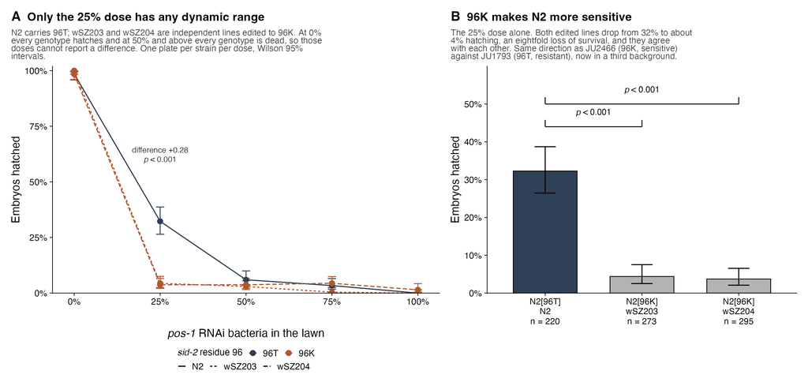

SUPP_FIG_XX_n2_swap_dose

A Every genotype at every dose: 0, 25, 50, 75 and 100% *pos-1* RNAi bacteria. N2 carries 96T; wSZ203 and wSZ204 are independent lines edited to 96K. One plate per strain per dose with Wilson 95% intervals.

B The 25% dose alone, as in Figure 4B.

| % pos-1 | 96T | 96K | Difference | Fisher p |
| --- | --- | --- | --- | --- |
| 0 | 0.985 | 0.992 | -0.006 | 0.43 |
| 25 | 0.323 | 0.040 | +0.282 | 8.0e-25 |
| 50 | 0.060 | 0.034 | +0.026 | 0.11 |
| 75 | 0.034 | 0.027 | +0.007 | 0.64 |
| 100 | 0.000 | 0.007 | -0.007 | 0.55 |

Derived from supplemental_data/hatching_assays/n2_allele_swaps_hatching.tsv

25% is not merely where the difference is largest (+0.282, Fisher 8.0e-25) — it is the only dose that can carry one. Every other dilution sits at the ceiling or the floor for all three genotypes. **A single-dose experiment at full strength would have found nothing** — worth stating, because it is also the likely reason a sub-maximal dose is needed to see *sid-2* alleles in a resistant background at all.

## Figure S12 — everything held back from Figure 4A

**Script** `scripts/SUPP_FIG_XX_sid2_allele_swaps_full.R` · 50% *pos-1* RNAi  
**Supports** Figure 4A · 7 constructs, both food conditions

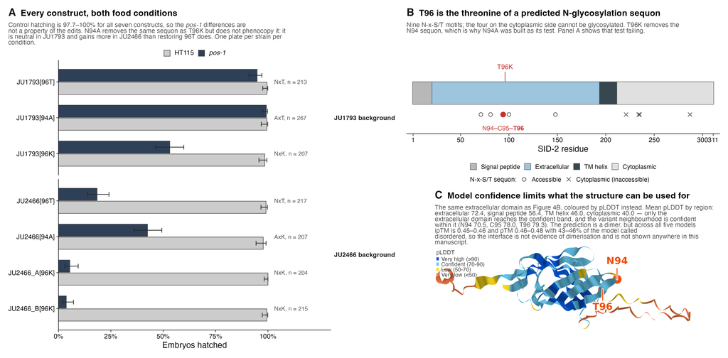

SUPP_FIG_XX_sid2_allele_swaps_full

A All seven constructs, HT115 and *pos-1*. Control hatching is 97.7–100% for every construct, so the *pos-1* differences are not a property of the edits.

B T96 is the threonine of an N94-C95-T96 sequon; nine N-x-S/T motifs are marked, and the four on the cytoplasmic side cannot be glycosylated.

C The ectodomain coloured by pLDDT, with per-domain means and the dimer ipTM values that limit what the structure can be used for.

Why the glycosylation hypothesis is not in Figure 4

N94A removes the same sequon as T96K while leaving residue 96 alone, and should phenocopy T96K if loss of the glycan is what matters. It does not:

| Background | Construct | Motif | Embryos | pos-1 hatching |
| --- | --- | --- | --- | --- |
| JU1793 | 96T (wt) | NxT | 213 | 0.948 |
| JU1793 | 94A | AxT | 267 | 0.993 |
| JU1793 | 96K | NxK | 207 | 0.531 |
| JU2466 | 96T | NxT | 217 | 0.184 |
| JU2466 | 94A | AxK | 207 | 0.425 |
| JU2466 | 96K (wt) | NxK | 419 | 0.045 |

Derived from supplemental_data/hatching_assays/ju_allele_swaps_hatching.csv

The AxT construct cannot be glycosylated at N94 and is fully resistant, so the glycan is not required for resistance; and removing Asn94 gains more in JU2466 (+0.38) than restoring Thr96 does (+0.14), while gaining almost nothing in JU1793 (+0.045). Positions 94 and 96 interact. A description that fits all six numbers is that Lys96 is deleterious and an unglycosylated Asn94 makes it worse, either relievable independently — **but that is epistasis between neighbouring residues, not a mechanism, and each genotype is a single plate.**

## Figure S13 — the honest negative check

**Script** `scripts/SUPP_FIG_XX_sid2_allele_in_panel.R`  
**Supports** the candidate, against the mapping panel  
**n** 230 of 231 phenotyped strains · site chrIII:13,680,248 C>A

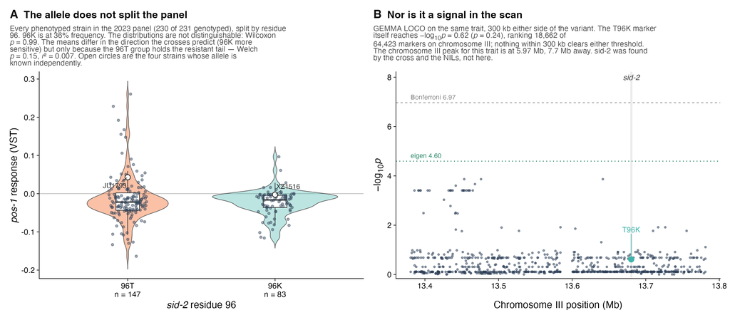

SUPP_FIG_XX_sid2_allele_in_panel

The T96K allele has no marginal effect across the mapping panel. This is a negative result and it is the honest check on the candidate.

B The association scan 300 kb either side of the variant. The T96K marker itself reaches `−log10 p = 0.62` (`p = 0.24`), ranking **18,662 of 64,423** markers on chromosome III, and nothing within 300 kb clears either threshold. The chromosome III peak for this trait is 7.7 Mb away, at 5.97 Mb.

How to say this in the text

This is not evidence against the allele; it is what a background-dependent effect looks like from a marginal test. The editing experiments put the T96K contribution at roughly half of the JU1793–JU2466 difference in one pair of backgrounds, and a 36%-frequency variant with an effect that context-dependent would not be expected to surface in a marginal scan of 231 strains. **It is worth stating plainly that *sid-2* was found by the cross and the NILs, not by the GWAS.**

## Figure S14 — surface charge of the ectodomain

**Script** `scripts/SUPP_FIG_XX_sid2_electrostatics.R`  
**Supports** Figure 4C, as hypothesis framing  
**Scope** residues 21–193 · gut lumen pH 4.4

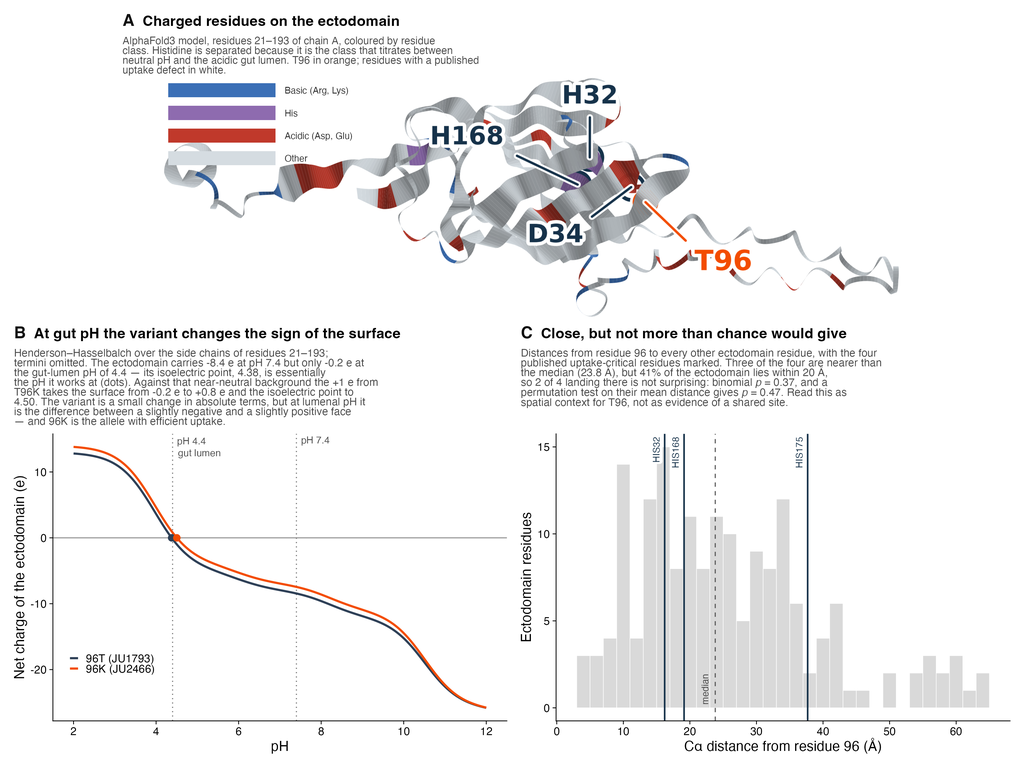

SUPP_FIG_XX_sid2_electrostatics

A hypothesis-framing figure: it estimates no binding affinity and contains no docking result.

A The ectodomain coloured by residue class, with histidine separated because it is the class that titrates between neutral pH and the acidic gut lumen. T96 in orange, the uptake-critical residues in white.

B Net charge against pH, by Henderson–Hasselbalch over the side chains of residues 21–193 (11 Asp, 7 Glu, 3 His, 4 Cys, 5 Tyr, 9 Lys, 1 Arg; termini omitted because the ectodomain runs into the transmembrane helix). The domain carries `−8.4 e` at pH 7.4 but only `−0.2 e` at the gut-lumen pH of 4.4, and its isoelectric point, 4.38, is essentially the pH it works at. Against that near-neutral background the +1 e from T96K takes the surface from −0.2 e to `+0.8 e` and the isoelectric point to 4.50 — a small change in absolute terms, but at lumenal pH it is the difference between a slightly negative and a slightly positive face, and **96K is the allele with efficient uptake**.

This corrects an earlier internal figure

The stage4 analysis in the structure-modelling folder reported the ectodomain flipping to *strongly* net positive at pH 4.4. It assigned fixed fractional charges of −0.240 to Asp and −0.334 to Glu, which correspond to pKa values near 3.4–3.7; with standard pKa values Asp is still about 76% ionised at pH 4.4 and the domain comes out close to electroneutral. **The numbers in panel B are the ones to quote.**

No potential map is shown, deliberately

The one in the structure-modelling folder is a Coulomb potential with a distance-dependent dielectric sampled on a plane 55 Å above the protein, in arbitrary units, with no ionic screening — and its headline panel is the difference between the T96 and K96 surfaces, necessarily a smooth positive blob centred on residue 96, since adding +1 e there cannot produce anything else. The HADDOCK dsRNA docking in the same folder is also unusable: positive HADDOCK scores (+98 to +200, where favourable is negative), interaction energies of order 1e4, restraint-violation energies of 480–1380, 4–13 structures per cluster, and different 91-residue active-residue lists between the two arms being compared.

# Diagnostics

## Leakage in the MIP-seq validation

**Script** `scripts/baugh_leakage_vs_similarity.R`  
**Asks** whether the strains the deconvolution resolves badly are the genetically similar ones  
**Predictor** `baugh_strain_similarity.tsv` — identity-by-state within the Baugh design matrix, the reference actually solved

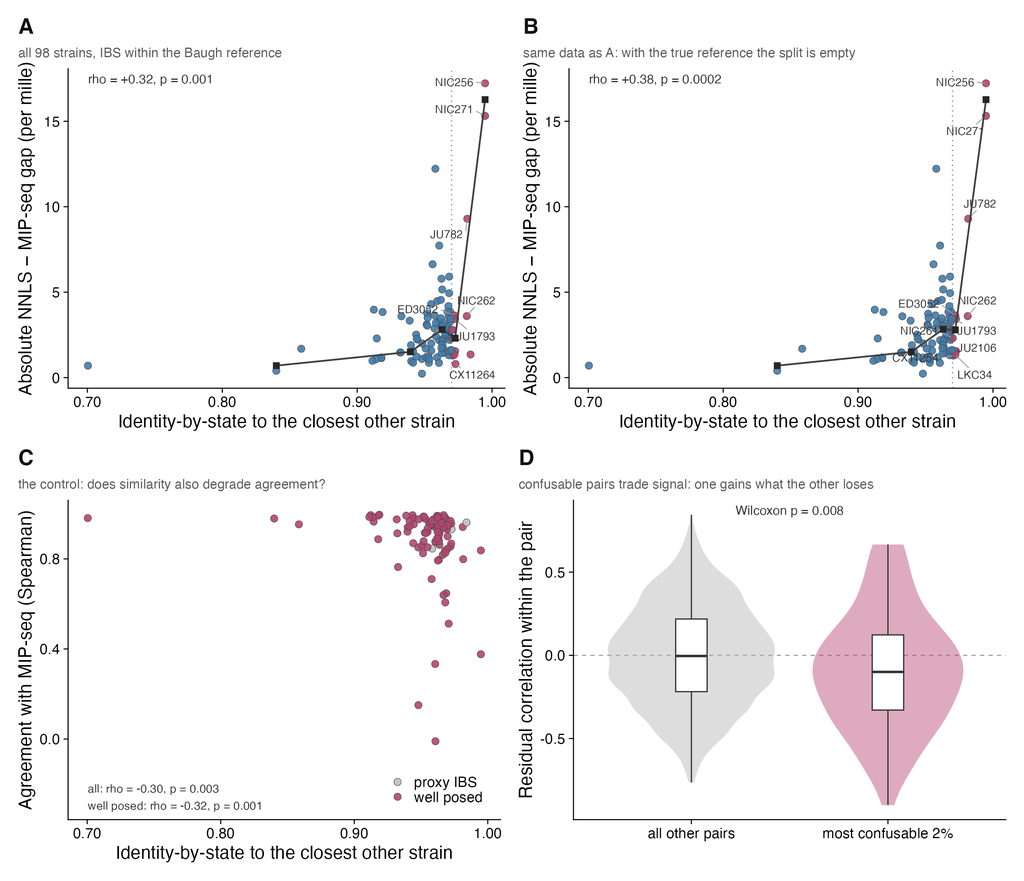

This ports the dilution experiment’s question to the one dataset with an independent measurement of the same material. Relatedness predicts NNLS–MIP-seq disagreement: ρ `+0.319` over all 98 strains (`p = 0.0014`), `+0.375` over the 95 whose nearest neighbour is itself measured here (`p = 0.00018`), surviving with abundance held constant. Confusable pairs trade signal — the most-confusable 2% of pairs have median residual correlation `−0.100` against `−0.004` for the rest (Wilcoxon `p = 0.0079`).

| Strain | Closest relative | IBS | NNLS slope | MIP slope | Ratio |
| --- | --- | --- | --- | --- | --- |
| NIC256 | NIC271 | 0.9948 | -1.37e-04 | -4.32e-04 | 0.32 |
| NIC271 | NIC256 | 0.9948 | 2.73e-05 | -5.87e-05 | -0.47 |
| PS2025 | ECA348 | 0.9841 | 7.67e-05 | 1.98e-04 | 0.39 |
| JU782 | NIC271 | 0.9816 | -5.26e-04 | -6.63e-04 | 0.79 |
| NIC262 | NIC271 | 0.9813 | 2.73e-04 | 4.88e-04 | 0.56 |
| CX11264 | CX11262 | 0.9729 | -5.20e-04 | -4.88e-04 | 1.07 |
| JU1793 | JU2106 | 0.9726 | -5.12e-04 | -5.84e-04 | 0.88 |
| JU2106 | JU1793 | 0.9726 | -4.79e-04 | -3.29e-04 | 1.46 |

Derived from baugh_nnls_with_mipseq.RData + baugh_strain_similarity.tsv

Does it reach the manuscript? Mostly not — and that is the finding

Two things protect the manuscript, and they stack.

**The reference here contains only pooled strains.** All 102 columns are strains that were in the pool, so the set-level leakage that costs the dilution experiment ~20% of each pure pool is **zero by construction**. That 20% is not a property of NNLS — it is what happens when the solver is offered 127 candidates that are not in the pool. The transferable finding is a **design rule**: restrict the reference to strains actually pooled.

**The phenotype is a change, and the error differences out.** Confusability is systematic across timepoints, so a pair splitting mass in constant proportion gets the level wrong and the change much less so:

| error measure | ρ vs relatedness | p |
| --- | --- | --- |
| per-sample frequency | `+0.322` | `0.0012` |
| fitted slope | `+0.130` | **`0.20`** |

Median slope error is `0.086` per mille for the 13 strains above IBS 0.97 against `0.075` for the other 85 — 1.15×, Mann-Whitney `p = 0.48`. The aggregation says it from the other side too: slopes agree at ρ `0.974` where per-sample frequencies agree at `0.835`. Every manuscript phenotype is a difference, so this applies throughout.

**Caveat on that conclusion.** `p = 0.20` at n = 98 is absence of evidence, and the effect falls from 0.322 to 0.130 rather than to zero. Read it as “no longer detectable at this n”, not “provably absent”.

**What still stands.** Individual strains at the extreme remain unreliable even in slopes — NIC256’s NNLS slope is 0.32× the MIP slope and NIC271’s has the *wrong sign* — so an extreme phenotypic outlier from that pair deserves a check before it is believed. And a single-timepoint frequency should not be used as a phenotype: that is where ρ +0.32 lives, and it is structured along kinship, the same axis a GWAS kinship matrix models.

## GWAS interval admission

**Script** `scripts/diagnostic_gwas_intervals.R`  
**Settles** how to admit a QTL from the association scan so an unsupported lone marker is excluded and a supported sub-Bonferroni region is kept

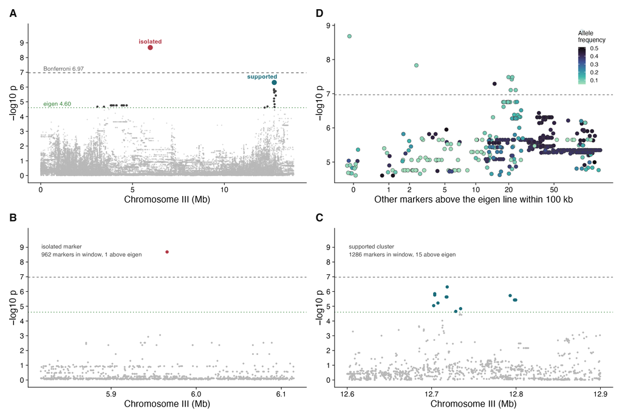

The marker at **5.966 Mb** clears Bonferroni (`8.68`) with **zero** other eigen-passing markers within 100 kb, out of 628 present. The cluster at **12.70–12.80 Mb** peaks *below* Bonferroni (`6.31`) with **14**. A threshold cannot separate them; local support can, and admission at ≥1 supporting marker excludes the first and keeps the second, stable up to k = 5.

Corroboration arrived independently: genome-wide, the 14 isolated markers have median allele frequency `0.082` against `0.394` for the 451 supported ones — the low-frequency signature of spurious association.

### Interval extent against the LD cutoff

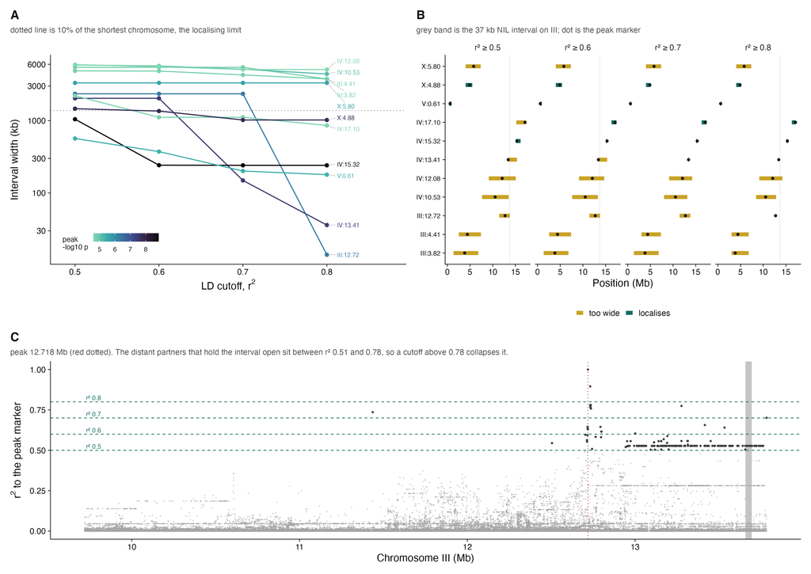

Admission by local support gives **11 loci** at the eigen threshold. Extent is then LD to the peak marker, and the cutoff matters enormously:

| locus | -log10 p | r² 0.5 | r² 0.6 | r² 0.7 | r² 0.8 |
| --- | --- | --- | --- | --- | --- |
| IV:15.32 | 8.84 | 1046 | 242 | 241 | 241 |
| X:4.88 | 7.83 | 1461 | 1355 | 1020 | 1020 |
| IV:13.41 | 7.49 | 2033 | 2033 | 149 | 36 |
| III:12.72 | 6.31 | 2347 | 2347 | 2347 | 14 |
| X:5.80 | 5.62 | 3322 | 3322 | 3322 | 3322 |
| V:0.61 | 5.40 | 566 | 373 | 201 | 179 |
| IV:10.53 | 5.17 | 5885 | 5682 | 5125 | 4411 |
| III:3.82 | 4.76 | 5453 | 5453 | 5453 | 3765 |
| III:4.41 | 4.76 | 4868 | 4839 | 4279 | 3765 |
| IV:17.10 | 4.70 | 2204 | 1111 | 1111 | 858 |
| IV:12.08 | 4.60 | 5939 | 5568 | 5081 | 5081 |

Derived from plots/diagnostics/TABLE_gwas_interval_r2_sweep_eigen.tsv — widths in kb

**Loci that localise** — interval under 10% of their chromosome — go `3`, `4`, `5`, `6` of 11 as the cutoff rises 0.5 → 0.8. It tracks signal strength: median peak −log₁₀p is `6.90` for the localising loci against `4.76` for the rest, because a marginal peak’s LD partners are scattered.

What this implies for the concordance claim, and it is cutoff-dependent

The chromosome III association locus at 12.718 Mb meets the NIL interval at r² 0.5, 0.6 **and** 0.7 — all giving a 2,347 kb interval, 17% of the chromosome — and collapses to **14 kb** at r² 0.8, sitting `0.93` Mb away. The signal-drop interval (97 kb) is `0.86` Mb away.

Panel C shows why. The peak’s distant LD partners span r² `0.505`–`0.775`, so any cutoff above 0.78 drops every one of them and the interval falls back to the local block. The plateau at 0.5–0.7 is held open by a marker at 13.784 Mb (r² `0.701`) — which is the chromosome’s **terminal marker**, the same boundary artefact that makes the cross scan’s peak position uninformative.

One distinction worth keeping: at r² 0.5 the overlap is **genuine** — 8 markers inside the NIL window reach r² ≈ `0.527` with the peak. At 0.6 and 0.7 no qualifying marker falls inside it, and the interval spans it only as a min–max hull. So the overlap is real only under the most permissive cutoff.

**The defensible statement** is that the association signal and the NIL interval are about 0.9 Mb apart, and that they coincide only under an interval definition wide enough to cover a sixth of chromosome III. That reads as a distinct locus, not concordance.

## Coverage against reference size

**Script** `scripts/diagnostic_reference_size.R`  
**Asks** how slope recovery degrades as coverage falls, and how much worse it gets as the reference admits candidates that are not in the pool

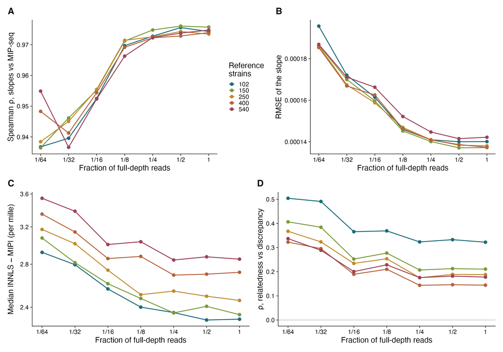

**A larger reference costs per-strain accuracy, and almost nothing in the slopes.** The 102 pooled strains are always present; larger references add candidates from the other 438 CeNDR isotypes. Depth is the fraction of full-depth reads retained, by binomial thinning of the archived alt counts (exact read thinning); full depth is 2.576 alt reads per marker, so absolute coverage is not recoverable from this archive and the axis is relative.

The reconstruction is validated rather than assumed: rebuilding the reference from CeNDR genotypes and applying the recovered flip mask reproduces the archive’s design matrix with **0 mismatching cells of 126,184,812**, and the deconvolution at reference 102 / full depth reproduces the archived frequencies with a **maximum difference of exactly 0** across 2,346 strain-samples.

| Depth (fraction) | Alt reads/marker | R=102 | R=150 | R=250 | R=400 | R=540 |
| --- | --- | --- | --- | --- | --- | --- |
| 1/64 | 0.040 | 0.937 | 0.936 | 0.938 | 0.948 | 0.955 |
| 1/32 | 0.080 | 0.940 | 0.946 | 0.945 | 0.941 | 0.937 |
| 1/16 | 0.161 | 0.952 | 0.955 | 0.955 | 0.954 | 0.952 |
| 1/8 | 0.322 | 0.970 | 0.971 | 0.971 | 0.969 | 0.966 |
| 1/4 | 0.644 | 0.973 | 0.975 | 0.973 | 0.972 | 0.972 |
| 1/2 | 1.288 | 0.976 | 0.976 | 0.974 | 0.973 | 0.974 |
| 1/1 | 2.576 | 0.974 | 0.976 | 0.973 | 0.974 | 0.975 |

Derived from plots/diagnostics/TABLE_reference_size_vs_coverage.tsv

Three things the surface says

**Slope recovery is flat in reference size.** At full depth ρ goes `0.974` at 102 candidates to `0.975` at 540; at 1/64 depth it is `0.937` against `0.955` — if anything slightly *better* with the larger reference. So a reference carrying five times as many absent candidates costs essentially nothing in the quantity the manuscript uses.

**Per-strain accuracy does pay.** Median |NNLS − MIP| rises from `2.30` to `2.85` per mille at full depth, a 24% increase, and from `2.92` to `3.54` at 1/64 depth. The cost is real but it lands on individual frequencies, not on fitted slopes — the same split as the leakage result above.

**Relatedness bites harder as coverage falls, and *less* as the reference grows.** ρ(nn_ibs, discrepancy) at reference 102 runs `0.322` at full depth up to `0.504` at 1/64 — confusability needs reads to resolve, as predicted. But at fixed depth it *falls* with reference size (`0.322` → `0.178` at full depth), because when every strain has a close relative among 540 candidates, nearest-neighbour identity stops discriminating. That is a property of the predictor losing range, not of the deconvolution improving.

## Off-pool leakage against coverage

**Script** `scripts/diagnostic_downsample_leakage.R`  
**Figure** `plots/diagnostics/downsample_leakage.png`

The section above measures *discrepancy* — how far a pool member’s estimated frequency sits from its MIP-seq measurement. This one measures *leakage*: frequency handed to reference columns that are not in the pool at all. They are different failure modes, and only the second is what a real experiment risks when it cannot name its own members. At 102 candidates leakage is zero by construction, because every column is a pool member; at 540 there are 438 columns that should carry nothing.

No deconvolution is rerun. The reference-size diagnostic saved every fitted frequency for all 540 columns and its own tables then dropped the absent ones in a join against the MIP-seq measurements, so these numbers come out of the same fit and cannot drift from what is reported above.

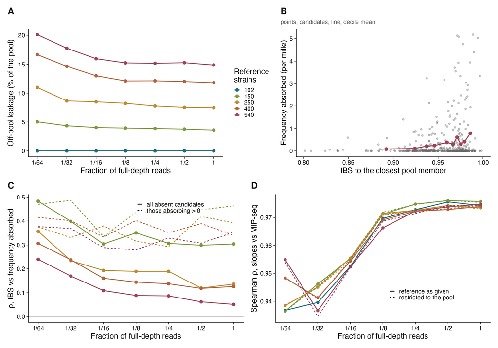

Median across samples of the pool frequency assigned to strains absent from the pool.

| Depth | R=150 | R=250 | R=400 | R=540 |
| --- | --- | --- | --- | --- |
| 1/64 | 5.03 | 10.99 | 16.67 | 20.11 |
| 1/32 | 4.36 | 8.65 | 14.64 | 17.77 |
| 1/16 | 4.05 | 8.49 | 13.00 | 15.96 |
| 1/8 | 3.96 | 8.24 | 12.11 | 15.24 |
| 1/4 | 3.89 | 7.78 | 12.14 | 15.17 |
| 1/2 | 3.78 | 7.54 | 12.01 | 15.27 |
| 1/1 | 3.62 | 7.47 | 11.81 | 14.87 |

Derived from plots/diagnostics/TABLE_downsample_leakage.tsv and TABLE_downsample_leakage_slopes.tsv

Both things are true at once

**Coverage is almost irrelevant to it.** Over a 64-fold depth reduction leakage at 540 candidates rises only from `14.9%` to `20.1%`, most of that in the last two halvings. Low coverage is not what makes an unknown membership list expensive, which was the thing worth checking and is not what I would have guessed.

**It is not spread evenly, and individual strains are displaced outright.** Among strain-samples above 0.5% of the pool the median retained fraction is `0.898`, but the 5–95% range is `0.396`–`1.04`. The cleanest case: ECA36 falls from `4.17` per mille at 102 candidates to `0.00` at 540, while JU3226 — absent from the pool, IBS `0.9898` to ECA36 — absorbs `4.39`. One strain is swapped for its look-alike almost exactly.

**And none of it reaches the phenotype.** Spearman agreement between NNLS growth slopes and MIP-seq slopes is `0.975` at 540 candidates against `0.974` at 102, with RMSE `0.0001` for both. Restricting the reference to the true pool and renormalising — what an experiment with a known membership list gets — moves the third decimal at most. The cost of not knowing the membership, as loss in ρ against the 102-candidate reference, is between `-0.001` and `+0.003` at every depth above 1/64.

So the answer to “is this a big deal” is: not for anything the manuscript claims. Per-strain identity degrades badly at the extreme of relatedness, and the slope phenotype behind Figure 1 and the pooled GWAS does not notice, because displacement is consistent across the samples of a replicate and so shifts a strain’s whole trajectory rather than its trend.

Relatedness grades the magnitude, not the membership

Panel C plots a whole-set rank correlation, and read alone it is misleading — it falls from `+0.304` at 150 candidates to `+0.051` at 540 and looks like a relationship dissolving. It is not. NNLS is non-negative, so its solutions are sparse: at 540 candidates and full depth `56.8%` of absent columns absorb *exactly* zero, and those ties flatten any Spearman.

Split in two, it resolves. IBS does **not** predict which candidates enter the solution’s support at all — logistic P(absorbs > 0) on IBS has slope `-1.13`, `p = 0.71`, and the rank correlation with the indicator is `-0.021`. Among the candidates that do absorb something, IBS predicts how much, and does so consistently at every reference size and depth: `+0.46`, `+0.39`, `+0.34`, `+0.35` at 150, 250, 400 and 540 at full depth, and between `+0.28` and `+0.49` across the whole grid. The whole-set decline is entirely the zero fraction climbing from `25%` to `57%`.

Panel B is the same fact in the form that matters: mean frequency absorbed rises `9.6`-fold across IBS deciles, from `0.081` per mille in the least related tenth of absent candidates to `0.785` in the most related. Decile *means* are plotted rather than medians for exactly the reason above — with 57% exact zeros every decile median is 0, which would draw a flat line through data that has a ten-fold gradient in it.

One incidental result worth keeping: sparsity increases with depth. The zero fraction at 540 candidates goes from `20.5%` at 1/64 depth to `56.8%` at full depth, so shallow sequencing does not just leak more in total — it spreads the leak across more wrong strains.

Full depth. The whole-set correlation tracks the zero fraction; the among-absorbers correlation does not move.

| Reference | Absent candidates | Absorbing exactly 0 | ρ, whole set | ρ, among absorbers |
| --- | --- | --- | --- | --- |
| 150 | 48 | 25.0% | +0.304 | +0.464 |
| 250 | 148 | 41.9% | +0.136 | +0.392 |
| 400 | 298 | 47.7% | +0.126 | +0.340 |
| 540 | 438 | 56.8% | +0.051 | +0.353 |

What is still not established

Which reference columns the solver admits into its support in the first place. That is a property of the collinearity of the whole design matrix, not of any one pairwise distance, and nothing measured here explains it — a strain’s IBS to its closest pool member carries no information about whether it absorbs anything (`p = 0.71`). The claim this section supports is about how much an admitted candidate takes, plus the wholesale displacement seen in the near-duplicate pairs above IBS ≈ 0.985. It does not support a story about which strains the deconvolution will choose to be wrong about.

## Figure S15 — where T96’s pocket sits in the charge distribution

**Script** `scripts/SUPP_FIG_XX_sid2_local_charge.R`  
**Supports** Figure 4C, the quantitative half  
**Scope** residues 21–188 · 12 Å neighbourhoods · pH 4.4

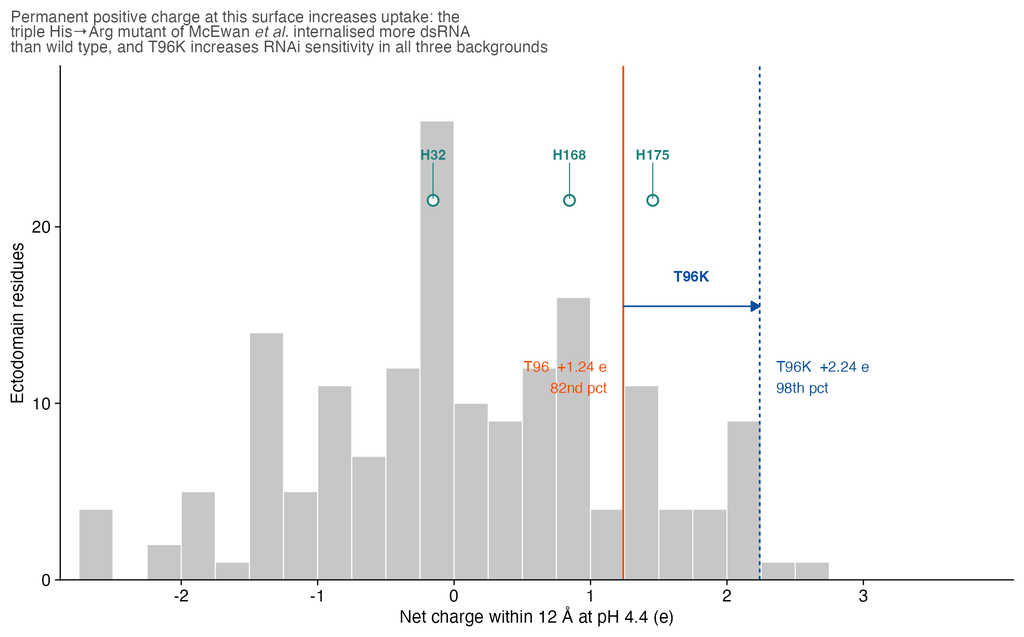

SUPP_FIG_XX_sid2_local_charge

Figure 4C shows *where* the positive pocket is. This shows *how unusual* it is, which is the part that can be argued with.

The claim, and its size

T96’s neighbourhood is `+1.24` e, the **82nd percentile** of the 168 ectodomain residues (median `0.00`); T96K takes it to `+2.24` e, the **98th**. The pocket is made by two lysines, K93 at `6.6` Å and K132 at `6.8` Å (`4.5` and `4.4` Å nearest heavy atom).

Two things stop this being over-read. `81` of the 168 residues have positive local charge at this pH, so a positive pocket by itself is unremarkable — the percentile is the claim, not the sign. And the domain is net **acidic** overall, so this is a basic pocket in an acidic domain, not a polybasic surface of the kind SID-1 uses.

## Figure S16 — model confidence, and the proximity null

**Script** `scripts/SUPP_FIG_XX_sid2_model_confidence.R`  
**Supports** Figure 4C, defensively  
**Scope** residues 21–188 · AlphaFold3 pLDDT

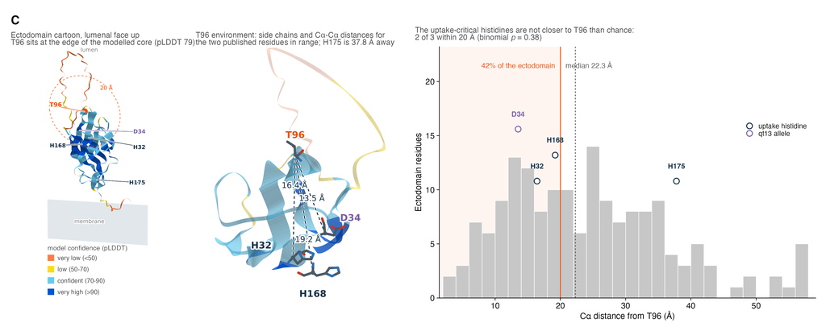

SUPP_FIG_XX_sid2_model_confidence

Figure 4C is coloured by charge and carries no confidence encoding, so this is where the model’s quality where it matters can be checked, and where the proximity null is shown rather than argued.

Two defensive points

**The model is sound where the claim is made.** `117` of the 168 ectodomain residues reach pLDDT ≥ 70, and T96 itself is at `79.3` — confident, though at the edge of the well-modelled core rather than deep inside it. The low-confidence region is the lumenal cap above T96, and nothing rests on the cap.

**The proximity argument is shown failing, not omitted.** `41.9%` of the ectodomain lies within 20 Å of T96, and two of the three uptake histidines fall inside that radius — binomial `p = 0.38`. The zoom keeps the two evidence classes apart, the histidines against the *qt13* allele D34, which is the distinction the released panel collapsed. `METHODS.txt` states that no proximity claim is made; this figure is why that can be stated rather than asserted.

## The panel split at two loci

**Script** `scripts/diagnostic_genotype_splits.R`  
**Figure** `plots/diagnostics/genotype_splits.png`

Two loci, asked separately and then together: `IV:15,323,414`, the strongest marker in the pooled scan, and `III:13,680,248`, *sid-2* T96K — the allele the cross and the NILs implicate. Higher VST is more resistant.

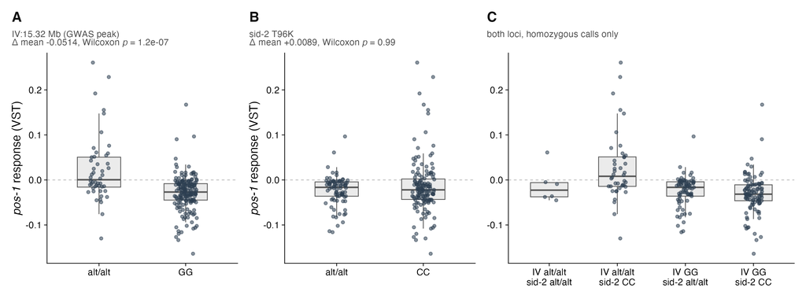

The marginal association each marker carries in the scan itself.

| Locus | AF | β | p (Wald) | −log₁₀p | Rank of 464,045 | Single-locus R² |
| --- | --- | --- | --- | --- | --- | --- |
| IV:15.32 Mb (GWAS peak) | 0.208 | +0.0258 | 0.000 | 8.84 | 1 | 0.159 |
| sid-2 T96K | 0.359 | -0.0050 | 0.243 | 0.62 | 101,105 | 0.007 |

Derived from plots/diagnostics/TABLE_genotype_splits.tsv and TABLE_genotype_splits_marginal.tsv

Chromosome IV is what this panel can see

Splitting at the chromosome IV peak separates `48` strains carrying the resistant allele (mean `+0.023`) from `182` carrying the other (`−0.029`): Δ = `−0.0514`, Wilcoxon `p = 1.2e-07`, which is **12% of the phenotypic range**. Its marginal statistic is the strongest in the scan — rank `1` of 464,045, `−log₁₀p = 8.84`, single-locus R² `0.159` — and in an additive two-locus fit it is the only term that carries anything: β `−0.052`, `p = 8e-10`, adjusted R² `0.152`.

So there is more than *sid-2* segregating for this trait in the wild population, and chromosome IV is the part of it the pooled GWAS is actually powered to find.

Why *sid-2* is invisible here, and why that is not a contradiction

Splitting at T96K separates `83` strains carrying 96K (mean `−0.024`) from `147` carrying 96T (`−0.015`). The direction is right — 96T more resistant, matching the allele swaps — but Δ = `+0.0089` with Wilcoxon `p = 0.99`, single-locus R² `0.007`, and a marginal rank of `101,105` of 464,045. In the additive fit, β = `−0.002`, `p = 0.74`.

**The two loci are not independent in the panel.** Fisher `p = 8.1e-05`, odds ratio `0.20`: only `6` of 230 strains carry 96K on the chromosome IV resistant background. The allele is largely confined to one background, so a marginal test at T96K is asking a question this panel cannot cleanly answer — which is a different statement from the allele having no effect.

# Open before submission

Everything above is generated and verified. These are the items that still need a decision or a number from outside the repository.

**Caption missing.** Figure 4 panel D has no entry in `FIGURE_CAPTIONS.txt`. The wild-variation panel was added after that file was generated, so the panel D caption above was written from the script header and the variant table rather than copied from the caption file. Fold it back so the two agree.

**Verify.** Published *sid-2* allele positions (residues 32, 34, 168, 175, 199) come from a UniProt annotation for `G5EEV9` recorded in earlier structure-modelling work. Check the residue numbers against UniProt directly — they carry the proximity argument in Figure 4C.

**To fill.** `METHODS.txt` has 17 `[TO FILL]` markers — husbandry, library prep, sequencing platform, editing protocol, the VST transform definition, what the bootstrap resampled, and GEMMA / GATK / DeepTMHMM / AlphaFold versions. The Dryad DOI is a placeholder in `DATA_AVAILABILITY.md`.

**Repository.** Two figure scripts in `scripts/legacy/` still resolve their working directory through the RStudio API and cannot run headless. `.git` remains ~380 MB because the untracked bulk data is still in history; shrinking it needs a history rewrite and a force-push.

# Figure manifest

| Number | File | Size (KB) | Modified |
| --- | --- | --- | --- |
| Figure S1 | SUPP_FIG_XX_simulation_depth | 390 | 2026-09-08 16:38 |
| Figure S2 | SUPP_FIG_XX_dilution_validation | 463 | 2026-09-08 16:38 |
| Figure 1 | Figure1_pos1 | 811 | 2026-09-08 16:38 |
| Figure S3 | SUPP_FIG_XX_baugh_per_sample_frequencies | 396 | 2026-09-08 16:38 |
| Figure S4 | SUPP_FIG_XX_bootstrap_propagation_checks | 448 | 2026-09-08 16:38 |
| Figure S5 | SUPP_FIG_XX_downsample_per_sample | 269 | 2026-09-08 16:38 |
| Figure S6 | SUPP_FIG_XX_original_pos1_dfreq_rep_correlation | 341 | 2026-09-08 16:38 |
| Figure S7 | SUPP_FIG_plate_vs_paaby_vs_pos1original | 199 | 2026-09-08 16:38 |
| Figure 2 | Figure2 | 1335 | 2026-09-08 16:38 |
| Figure S8 | SUPP_FIG_XX_pooled_phenotype_ranks | 132 | 2026-09-08 16:38 |
| Figure S9 | SUPP_FIG_XX_cross_contrast_panels | 966 | 2026-09-08 16:38 |
| Figure 3 | Figure3_quad | 172 | 2026-09-08 16:38 |
| Figure S10 | SUPP_FIG_XX_nil_hatching_full | 163 | 2026-09-08 16:38 |
| Figure 4 | Figure4_sid2 | 552 | 2026-09-08 16:38 |
| Figure S11 | SUPP_FIG_XX_n2_swap_dose | 240 | 2026-09-08 16:38 |
| Figure S12 | SUPP_FIG_XX_sid2_allele_swaps_full | 562 | 2026-09-08 16:38 |
| Figure S13 | SUPP_FIG_XX_sid2_allele_in_panel | 486 | 2026-09-08 16:38 |
| Figure S14 | SUPP_FIG_XX_sid2_electrostatics | 794 | 2026-09-08 16:38 |
| Figure S15 | SUPP_FIG_XX_sid2_local_charge | 96 | 2026-09-08 16:38 |
| Figure S16 | SUPP_FIG_XX_sid2_model_confidence | 441 | 2026-09-08 16:38 |